# opioid receptor

```python
import pandas as pd
from chembl_webresource_client.new_client import new_client
```

```python
target = new_client.target
target_query = target.search('CHEMBL233')
targets = pd.DataFrame.from_dict(target_query)
targets
```

|  | cross_references | organism | pref_name | score | species_group_flag | target_chembl_id | target_components | target_type | tax_id |
| --- | --- | --- | --- | --- | --- | --- | --- | --- | --- |
| 0 | [] | Homo sapiens | Mu opioid receptor | 12.0 | False | CHEMBL233 | [{'accession': 'P35372', 'component_descriptio... | SINGLE PROTEIN | 9606 |
| 1 | [] | Homo sapiens | CCR5/mu opioid receptor complex | 8.0 | False | CHEMBL3301384 | [{'accession': 'P51681', 'component_descriptio... | PROTEIN COMPLEX | 9606 |
| 2 | [] | Homo sapiens | Opioid receptors; mu & delta | 7.0 | False | CHEMBL2095149 | [{'accession': 'P41143', 'component_descriptio... | SELECTIVITY GROUP | 9606 |
| 3 | [] | Homo sapiens | Opioid receptors; mu & kappa | 7.0 | False | CHEMBL2095156 | [{'accession': 'P41145', 'component_descriptio... | SELECTIVITY GROUP | 9606 |
| 4 | [] | Homo sapiens | Mu opioid receptor/Alpha-2A adrenergic receptor | 7.0 | False | CHEMBL3883321 | [{'accession': 'P08913', 'component_descriptio... | PROTEIN COMPLEX | 9606 |
| 5 | [] | Homo sapiens | Cannabinoid receptor 1/Mu-type opioid receptor | 7.0 | False | CHEMBL3885538 | [{'accession': 'P21554', 'component_descriptio... | PROTEIN COMPLEX | 9606 |
| 6 | [] | Homo sapiens | Opioid receptors; mu/kappa/delta | 6.0 | False | CHEMBL2095181 | [{'accession': 'P41145', 'component_descriptio... | PROTEIN FAMILY | 9606 |

```python
selected_target = targets.target_chembl_id[0]
selected_target
```

```
'CHEMBL233'
```

```python
activity = new_client.activity
res = activity.filter(target_chembl_id=selected_target).filter(standard_type="IC50")
```

```python
df = pd.DataFrame.from_dict(res)
```

```python
print(len(res))
```

```
2452
```

```python
df.head()
```

|  | action_type | activity_comment | activity_id | activity_properties | assay_chembl_id | assay_description | assay_type | assay_variant_accession | assay_variant_mutation | bao_endpoint | ... | target_organism | target_pref_name | target_tax_id | text_value | toid | type | units | uo_units | upper_value | value |
| --- | --- | --- | --- | --- | --- | --- | --- | --- | --- | --- | --- | --- | --- | --- | --- | --- | --- | --- | --- | --- | --- |
| 0 | None | None | 32544 | [] | CHEMBL749749 | Binding affinity on cloned opioid receptor mu ... | B | None | None | BAO_0000190 | ... | Homo sapiens | Mu opioid receptor | 9606 | None | None | IC50 | nM | UO_0000065 | None | 5250.0 |
| 1 | None | None | 33756 | [] | CHEMBL749749 | Binding affinity on cloned opioid receptor mu ... | B | None | None | BAO_0000190 | ... | Homo sapiens | Mu opioid receptor | 9606 | None | None | IC50 | nM | UO_0000065 | None | 3480.0 |
| 2 | None | None | 38634 | [] | CHEMBL749749 | Binding affinity on cloned opioid receptor mu ... | B | None | None | BAO_0000190 | ... | Homo sapiens | Mu opioid receptor | 9606 | None | None | IC50 | nM | UO_0000065 | None | 320.0 |
| 3 | None | None | 38643 | [] | CHEMBL749749 | Binding affinity on cloned opioid receptor mu ... | B | None | None | BAO_0000190 | ... | Homo sapiens | Mu opioid receptor | 9606 | None | None | IC50 | nM | UO_0000065 | None | 4130.0 |
| 4 | None | None | 39754 | [] | CHEMBL749749 | Binding affinity on cloned opioid receptor mu ... | B | None | None | BAO_0000190 | ... | Homo sapiens | Mu opioid receptor | 9606 | None | None | IC50 | nM | UO_0000065 | None | 10000.0 |

5 rows × 46 columns

```python
df.tail()
```

|  | action_type | activity_comment | activity_id | activity_properties | assay_chembl_id | assay_description | assay_type | assay_variant_accession | assay_variant_mutation | bao_endpoint | ... | target_organism | target_pref_name | target_tax_id | text_value | toid | type | units | uo_units | upper_value | value |
| --- | --- | --- | --- | --- | --- | --- | --- | --- | --- | --- | --- | --- | --- | --- | --- | --- | --- | --- | --- | --- | --- |
| 2447 | {'action_type': 'ANTAGONIST', 'description': '... | None | 25631924 | [] | CHEMBL5365899 | Antagonist activity at human mu opioid recepto... | F | None | None | BAO_0000190 | ... | Homo sapiens | Mu opioid receptor | 9606 | None | None | IC50 | nM | UO_0000065 | None | 210.0 |
| 2448 | {'action_type': 'ANTAGONIST', 'description': '... | None | 25631925 | [] | CHEMBL5365899 | Antagonist activity at human mu opioid recepto... | F | None | None | BAO_0000190 | ... | Homo sapiens | Mu opioid receptor | 9606 | None | None | IC50 | nM | UO_0000065 | None | 110.0 |
| 2449 | {'action_type': 'ANTAGONIST', 'description': '... | None | 25631926 | [] | CHEMBL5365899 | Antagonist activity at human mu opioid recepto... | F | None | None | BAO_0000190 | ... | Homo sapiens | Mu opioid receptor | 9606 | None | None | IC50 | nM | UO_0000065 | None | 29.0 |
| 2450 | None | None | 25778419 | [{'comments': None, 'relation': '=', 'result_f... | CHEMBL5465602 | Selectivity interaction (BET inhibitor selecti... | B | None | None | BAO_0000190 | ... | Homo sapiens | Mu opioid receptor | 9606 | None | None | IC50 | uM | UO_0000065 | None | 100.0 |
| 2451 | None | None | 25787567 | [{'comments': None, 'relation': None, 'result_... | CHEMBL5474455 | Selectivity interaction (Opioid Mu GTPgS agoni... | B | None | None | BAO_0000190 | ... | Homo sapiens | Mu opioid receptor | 9606 | None | None | IC50 | uM | UO_0000065 | None | 30.0 |

5 rows × 46 columns

```python
df.info()
df.columns
```

```
<class 'pandas.core.frame.DataFrame'>
RangeIndex: 2452 entries, 0 to 2451
Data columns (total 46 columns):
 #   Column                     Non-Null Count  Dtype
---  ------                     --------------  -----
 0   action_type                66 non-null     object
 1   activity_comment           1181 non-null   object
 2   activity_id                2452 non-null   int64
 3   activity_properties        2452 non-null   object
 4   assay_chembl_id            2452 non-null   object
 5   assay_description          2452 non-null   object
 6   assay_type                 2452 non-null   object
 7   assay_variant_accession    0 non-null      object
 8   assay_variant_mutation     0 non-null      object
 9   bao_endpoint               2452 non-null   object
```

[output cut: 38 more lines]

```
Index(['action_type', 'activity_comment', 'activity_id', 'activity_properties',
       'assay_chembl_id', 'assay_description', 'assay_type',
       'assay_variant_accession', 'assay_variant_mutation', 'bao_endpoint',
       'bao_format', 'bao_label', 'canonical_smiles', 'data_validity_comment',
       'data_validity_description', 'document_chembl_id', 'document_journal',
       'document_year', 'ligand_efficiency', 'molecule_chembl_id',
       'molecule_pref_name', 'parent_molecule_chembl_id', 'pchembl_value',
       'potential_duplicate', 'qudt_units', 'record_id', 'relation', 'src_id',
       'standard_flag', 'standard_relation', 'standard_text_value',
       'standard_type', 'standard_units', 'standard_upper_value',
       'standard_value', 'target_chembl_id', 'target_organism',
       'target_pref_name', 'target_tax_id', 'text_value', 'toid', 'type',
       'units', 'uo_units', 'upper_value', 'value'],
      dtype='object')
```

```python
df2 = df.dropna(subset=["standard_value", "canonical_smiles"])
```

```python
df2
```

|  | action_type | activity_comment | activity_id | activity_properties | assay_chembl_id | assay_description | assay_type | assay_variant_accession | assay_variant_mutation | bao_endpoint | ... | target_organism | target_pref_name | target_tax_id | text_value | toid | type | units | uo_units | upper_value | value |
| --- | --- | --- | --- | --- | --- | --- | --- | --- | --- | --- | --- | --- | --- | --- | --- | --- | --- | --- | --- | --- | --- |
| 0 | None | None | 32544 | [] | CHEMBL749749 | Binding affinity on cloned opioid receptor mu ... | B | None | None | BAO_0000190 | ... | Homo sapiens | Mu opioid receptor | 9606 | None | None | IC50 | nM | UO_0000065 | None | 5250.0 |
| 1 | None | None | 33756 | [] | CHEMBL749749 | Binding affinity on cloned opioid receptor mu ... | B | None | None | BAO_0000190 | ... | Homo sapiens | Mu opioid receptor | 9606 | None | None | IC50 | nM | UO_0000065 | None | 3480.0 |
| 2 | None | None | 38634 | [] | CHEMBL749749 | Binding affinity on cloned opioid receptor mu ... | B | None | None | BAO_0000190 | ... | Homo sapiens | Mu opioid receptor | 9606 | None | None | IC50 | nM | UO_0000065 | None | 320.0 |
| 3 | None | None | 38643 | [] | CHEMBL749749 | Binding affinity on cloned opioid receptor mu ... | B | None | None | BAO_0000190 | ... | Homo sapiens | Mu opioid receptor | 9606 | None | None | IC50 | nM | UO_0000065 | None | 4130.0 |
| 4 | None | None | 39754 | [] | CHEMBL749749 | Binding affinity on cloned opioid receptor mu ... | B | None | None | BAO_0000190 | ... | Homo sapiens | Mu opioid receptor | 9606 | None | None | IC50 | nM | UO_0000065 | None | 10000.0 |
| ... | ... | ... | ... | ... | ... | ... | ... | ... | ... | ... | ... | ... | ... | ... | ... | ... | ... | ... | ... | ... | ... |
| 2447 | {'action_type': 'ANTAGONIST', 'description': '... | None | 25631924 | [] | CHEMBL5365899 | Antagonist activity at human mu opioid recepto... | F | None | None | BAO_0000190 | ... | Homo sapiens | Mu opioid receptor | 9606 | None | None | IC50 | nM | UO_0000065 | None | 210.0 |
| 2448 | {'action_type': 'ANTAGONIST', 'description': '... | None | 25631925 | [] | CHEMBL5365899 | Antagonist activity at human mu opioid recepto... | F | None | None | BAO_0000190 | ... | Homo sapiens | Mu opioid receptor | 9606 | None | None | IC50 | nM | UO_0000065 | None | 110.0 |
| 2449 | {'action_type': 'ANTAGONIST', 'description': '... | None | 25631926 | [] | CHEMBL5365899 | Antagonist activity at human mu opioid recepto... | F | None | None | BAO_0000190 | ... | Homo sapiens | Mu opioid receptor | 9606 | None | None | IC50 | nM | UO_0000065 | None | 29.0 |
| 2450 | None | None | 25778419 | [{'comments': None, 'relation': '=', 'result_f... | CHEMBL5465602 | Selectivity interaction (BET inhibitor selecti... | B | None | None | BAO_0000190 | ... | Homo sapiens | Mu opioid receptor | 9606 | None | None | IC50 | uM | UO_0000065 | None | 100.0 |
| 2451 | None | None | 25787567 | [{'comments': None, 'relation': None, 'result_... | CHEMBL5474455 | Selectivity interaction (Opioid Mu GTPgS agoni... | B | None | None | BAO_0000190 | ... | Homo sapiens | Mu opioid receptor | 9606 | None | None | IC50 | uM | UO_0000065 | None | 30.0 |

1509 rows × 46 columns

```python
len(df2.canonical_smiles.unique())
```

```
1301
```

```python
df2_nr = df2.drop_duplicates(subset="canonical_smiles", keep="first").reset_index(drop=True)
```

```python
df2_nr
```

|  | action_type | activity_comment | activity_id | activity_properties | assay_chembl_id | assay_description | assay_type | assay_variant_accession | assay_variant_mutation | bao_endpoint | ... | target_organism | target_pref_name | target_tax_id | text_value | toid | type | units | uo_units | upper_value | value |
| --- | --- | --- | --- | --- | --- | --- | --- | --- | --- | --- | --- | --- | --- | --- | --- | --- | --- | --- | --- | --- | --- |
| 0 | None | None | 32544 | [] | CHEMBL749749 | Binding affinity on cloned opioid receptor mu ... | B | None | None | BAO_0000190 | ... | Homo sapiens | Mu opioid receptor | 9606 | None | None | IC50 | nM | UO_0000065 | None | 5250.0 |
| 1 | None | None | 33756 | [] | CHEMBL749749 | Binding affinity on cloned opioid receptor mu ... | B | None | None | BAO_0000190 | ... | Homo sapiens | Mu opioid receptor | 9606 | None | None | IC50 | nM | UO_0000065 | None | 3480.0 |
| 2 | None | None | 38634 | [] | CHEMBL749749 | Binding affinity on cloned opioid receptor mu ... | B | None | None | BAO_0000190 | ... | Homo sapiens | Mu opioid receptor | 9606 | None | None | IC50 | nM | UO_0000065 | None | 320.0 |
| 3 | None | None | 38643 | [] | CHEMBL749749 | Binding affinity on cloned opioid receptor mu ... | B | None | None | BAO_0000190 | ... | Homo sapiens | Mu opioid receptor | 9606 | None | None | IC50 | nM | UO_0000065 | None | 4130.0 |
| 4 | None | None | 39754 | [] | CHEMBL749749 | Binding affinity on cloned opioid receptor mu ... | B | None | None | BAO_0000190 | ... | Homo sapiens | Mu opioid receptor | 9606 | None | None | IC50 | nM | UO_0000065 | None | 10000.0 |
| ... | ... | ... | ... | ... | ... | ... | ... | ... | ... | ... | ... | ... | ... | ... | ... | ... | ... | ... | ... | ... | ... |
| 1296 | {'action_type': 'ANTAGONIST', 'description': '... | None | 25631924 | [] | CHEMBL5365899 | Antagonist activity at human mu opioid recepto... | F | None | None | BAO_0000190 | ... | Homo sapiens | Mu opioid receptor | 9606 | None | None | IC50 | nM | UO_0000065 | None | 210.0 |
| 1297 | {'action_type': 'ANTAGONIST', 'description': '... | None | 25631925 | [] | CHEMBL5365899 | Antagonist activity at human mu opioid recepto... | F | None | None | BAO_0000190 | ... | Homo sapiens | Mu opioid receptor | 9606 | None | None | IC50 | nM | UO_0000065 | None | 110.0 |
| 1298 | {'action_type': 'ANTAGONIST', 'description': '... | None | 25631926 | [] | CHEMBL5365899 | Antagonist activity at human mu opioid recepto... | F | None | None | BAO_0000190 | ... | Homo sapiens | Mu opioid receptor | 9606 | None | None | IC50 | nM | UO_0000065 | None | 29.0 |
| 1299 | None | None | 25778419 | [{'comments': None, 'relation': '=', 'result_f... | CHEMBL5465602 | Selectivity interaction (BET inhibitor selecti... | B | None | None | BAO_0000190 | ... | Homo sapiens | Mu opioid receptor | 9606 | None | None | IC50 | uM | UO_0000065 | None | 100.0 |
| 1300 | None | None | 25787567 | [{'comments': None, 'relation': None, 'result_... | CHEMBL5474455 | Selectivity interaction (Opioid Mu GTPgS agoni... | B | None | None | BAO_0000190 | ... | Homo sapiens | Mu opioid receptor | 9606 | None | None | IC50 | uM | UO_0000065 | None | 30.0 |

1301 rows × 46 columns

```python
df2_nr.columns
```

```
Index(['action_type', 'activity_comment', 'activity_id', 'activity_properties',
       'assay_chembl_id', 'assay_description', 'assay_type',
       'assay_variant_accession', 'assay_variant_mutation', 'bao_endpoint',
       'bao_format', 'bao_label', 'canonical_smiles', 'data_validity_comment',
       'data_validity_description', 'document_chembl_id', 'document_journal',
       'document_year', 'ligand_efficiency', 'molecule_chembl_id',
       'molecule_pref_name', 'parent_molecule_chembl_id', 'pchembl_value',
       'potential_duplicate', 'qudt_units', 'record_id', 'relation', 'src_id',
       'standard_flag', 'standard_relation', 'standard_text_value',
       'standard_type', 'standard_units', 'standard_upper_value',
       'standard_value', 'target_chembl_id', 'target_organism',
       'target_pref_name', 'target_tax_id', 'text_value', 'toid', 'type',
       'units', 'uo_units', 'upper_value', 'value'],
      dtype='object')
```

## Data pre-processing of the bioactivity data

```python
selection = ['molecule_chembl_id','canonical_smiles','standard_value']
df3 = df2_nr[selection]
df3
```

|  | molecule_chembl_id | canonical_smiles | standard_value |
| --- | --- | --- | --- |
| 0 | CHEMBL423694 | CCN(CC)C(=O)c1ccc(C(=C2CCNCC2)c2cccc(OC)c2)cc1 | 5250.0 |
| 1 | CHEMBL278078 | CCN(CC)C(=O)c1ccc(C(=C2CCNCC2)c2ccccc2OC)cc1 | 3480.0 |
| 2 | CHEMBL13470 | C=CCN1C[C@H](C)N([C@H](c2ccc(C(=O)N(CC)CC)cc2)... | 320.0 |
| 3 | CHEMBL127802 | CCCCN1CCC(=C(c2ccccc2)c2ccc(C(=O)N(CC)CC)cc2)CC1 | 4130.0 |
| 4 | CHEMBL126946 | CCN(CC)C(=O)c1ccc(C(=C2CCNCC2)c2ccc(F)cc2)cc1 | 10000.0 |
| ... | ... | ... | ... |
| 1296 | CHEMBL5429557 | CN(C)[C@H](CNC(=O)[C@H]1C[C@]1(C)c1ccccc1)Cc1c... | 210.0 |
| 1297 | CHEMBL5397104 | CN(C)[C@H](CNC(=O)[C@@H]1C[C@]1(C)c1ccccc1)Cc1... | 110.0 |
| 1298 | CHEMBL5414957 | CN(C)[C@H](CNC(=O)[C@@H]1C[C@]1(C)c1ccccc1)Cc1... | 29.0 |
| 1299 | CHEMBL2017291 | COc1cc2c(cc1-c1c(C)noc1C)ncc1[nH]c(=O)n([C@H](... | 100000.0 |
| 1300 | CHEMBL3643413 | CCC(=O)N1CC[C@H](Nc2ncnc3c2CN(c2cnc(OC)c(C(F)(... | 30000.0 |

1301 rows × 3 columns

## Labeling compounds as either being active, inactive or intermediate

#### The bioactivity data is in the IC50 unit. Compounds having values of less than 1000 nM will be considered to be active while those greater than 10,000 nM will be considered to be inactive. As for those values in between 1,000 and 10,000 nM will be referred to as intermediate.

```python
bioactivity_threshold = []
for i in df3.standard_value:
  if float(i) >= 10000:
    bioactivity_threshold.append("inactive")
  elif float(i) <= 1000:
    bioactivity_threshold.append("active")
  else:
    bioactivity_threshold.append("intermediate")
```

```python
bioactivity_class = pd.Series(bioactivity_threshold, name='class')
df5 = pd.concat([df3, bioactivity_class], axis=1)
df5
```

|  | molecule_chembl_id | canonical_smiles | standard_value | class |
| --- | --- | --- | --- | --- |
| 0 | CHEMBL423694 | CCN(CC)C(=O)c1ccc(C(=C2CCNCC2)c2cccc(OC)c2)cc1 | 5250.0 | intermediate |
| 1 | CHEMBL278078 | CCN(CC)C(=O)c1ccc(C(=C2CCNCC2)c2ccccc2OC)cc1 | 3480.0 | intermediate |
| 2 | CHEMBL13470 | C=CCN1C[C@H](C)N([C@H](c2ccc(C(=O)N(CC)CC)cc2)... | 320.0 | active |
| 3 | CHEMBL127802 | CCCCN1CCC(=C(c2ccccc2)c2ccc(C(=O)N(CC)CC)cc2)CC1 | 4130.0 | intermediate |
| 4 | CHEMBL126946 | CCN(CC)C(=O)c1ccc(C(=C2CCNCC2)c2ccc(F)cc2)cc1 | 10000.0 | inactive |
| ... | ... | ... | ... | ... |
| 1296 | CHEMBL5429557 | CN(C)[C@H](CNC(=O)[C@H]1C[C@]1(C)c1ccccc1)Cc1c... | 210.0 | active |
| 1297 | CHEMBL5397104 | CN(C)[C@H](CNC(=O)[C@@H]1C[C@]1(C)c1ccccc1)Cc1... | 110.0 | active |
| 1298 | CHEMBL5414957 | CN(C)[C@H](CNC(=O)[C@@H]1C[C@]1(C)c1ccccc1)Cc1... | 29.0 | active |
| 1299 | CHEMBL2017291 | COc1cc2c(cc1-c1c(C)noc1C)ncc1[nH]c(=O)n([C@H](... | 100000.0 | inactive |
| 1300 | CHEMBL3643413 | CCC(=O)N1CC[C@H](Nc2ncnc3c2CN(c2cnc(OC)c(C(F)(... | 30000.0 | inactive |

1301 rows × 4 columns

```python
df5.to_csv('opioid receptor_03_bioactivity_data_curated.csv', index=False)
```

```python
df = pd.read_csv(r"C:\Users\manoj\OneDrive\Desktop\opioid receptor\opioid receptor_03_bioactivity_data_curated.csv")
df
```

|  | molecule_chembl_id | canonical_smiles | standard_value | class |
| --- | --- | --- | --- | --- |
| 0 | CHEMBL423694 | CCN(CC)C(=O)c1ccc(C(=C2CCNCC2)c2cccc(OC)c2)cc1 | 5250.0 | intermediate |
| 1 | CHEMBL278078 | CCN(CC)C(=O)c1ccc(C(=C2CCNCC2)c2ccccc2OC)cc1 | 3480.0 | intermediate |
| 2 | CHEMBL13470 | C=CCN1C[C@H](C)N([C@H](c2ccc(C(=O)N(CC)CC)cc2)... | 320.0 | active |
| 3 | CHEMBL127802 | CCCCN1CCC(=C(c2ccccc2)c2ccc(C(=O)N(CC)CC)cc2)CC1 | 4130.0 | intermediate |
| 4 | CHEMBL126946 | CCN(CC)C(=O)c1ccc(C(=C2CCNCC2)c2ccc(F)cc2)cc1 | 10000.0 | inactive |
| ... | ... | ... | ... | ... |
| 1296 | CHEMBL5429557 | CN(C)[C@H](CNC(=O)[C@H]1C[C@]1(C)c1ccccc1)Cc1c... | 210.0 | active |
| 1297 | CHEMBL5397104 | CN(C)[C@H](CNC(=O)[C@@H]1C[C@]1(C)c1ccccc1)Cc1... | 110.0 | active |
| 1298 | CHEMBL5414957 | CN(C)[C@H](CNC(=O)[C@@H]1C[C@]1(C)c1ccccc1)Cc1... | 29.0 | active |
| 1299 | CHEMBL2017291 | COc1cc2c(cc1-c1c(C)noc1C)ncc1[nH]c(=O)n([C@H](... | 100000.0 | inactive |
| 1300 | CHEMBL3643413 | CCC(=O)N1CC[C@H](Nc2ncnc3c2CN(c2cnc(OC)c(C(F)(... | 30000.0 | inactive |

1301 rows × 4 columns

```python
df_no_smiles = df.drop(columns='canonical_smiles')
```

```python
smiles = []

for i in df.canonical_smiles.tolist():
  cpd = str(i).split('.')
  cpd_longest = max(cpd, key = len)
  smiles.append(cpd_longest)

smiles = pd.Series(smiles, name = 'canonical_smiles')
```

```python
df_clean_smiles = pd.concat([df_no_smiles,smiles], axis=1)
df_clean_smiles
```

|  | molecule_chembl_id | standard_value | class | canonical_smiles |
| --- | --- | --- | --- | --- |
| 0 | CHEMBL423694 | 5250.0 | intermediate | CCN(CC)C(=O)c1ccc(C(=C2CCNCC2)c2cccc(OC)c2)cc1 |
| 1 | CHEMBL278078 | 3480.0 | intermediate | CCN(CC)C(=O)c1ccc(C(=C2CCNCC2)c2ccccc2OC)cc1 |
| 2 | CHEMBL13470 | 320.0 | active | C=CCN1C[C@H](C)N([C@H](c2ccc(C(=O)N(CC)CC)cc2)... |
| 3 | CHEMBL127802 | 4130.0 | intermediate | CCCCN1CCC(=C(c2ccccc2)c2ccc(C(=O)N(CC)CC)cc2)CC1 |
| 4 | CHEMBL126946 | 10000.0 | inactive | CCN(CC)C(=O)c1ccc(C(=C2CCNCC2)c2ccc(F)cc2)cc1 |
| ... | ... | ... | ... | ... |
| 1296 | CHEMBL5429557 | 210.0 | active | CN(C)[C@H](CNC(=O)[C@H]1C[C@]1(C)c1ccccc1)Cc1c... |
| 1297 | CHEMBL5397104 | 110.0 | active | CN(C)[C@H](CNC(=O)[C@@H]1C[C@]1(C)c1ccccc1)Cc1... |
| 1298 | CHEMBL5414957 | 29.0 | active | CN(C)[C@H](CNC(=O)[C@@H]1C[C@]1(C)c1ccccc1)Cc1... |
| 1299 | CHEMBL2017291 | 100000.0 | inactive | COc1cc2c(cc1-c1c(C)noc1C)ncc1[nH]c(=O)n([C@H](... |
| 1300 | CHEMBL3643413 | 30000.0 | inactive | CCC(=O)N1CC[C@H](Nc2ncnc3c2CN(c2cnc(OC)c(C(F)(... |

1301 rows × 4 columns

### Calculate Lipinski descriptors

#### Christopher Lipinski, a scientist at Pfizer, came up with a set of rule-of-thumb for evaluating the druglikeness of compounds. Such druglikeness is based on the Absorption, Distribution, Metabolism and Excretion (ADME) that is also known as the pharmacokinetic profile. Lipinski analyzed all orally active FDA-approved drugs in the formulation of what is to be known as the Rule-of-Five or Lipinski's Rule.

The Lipinski's Rule stated the following:

Molecular weight < 500 Dalton Octanol-water partition coefficient (LogP) < 5 Hydrogen bond donors < 5 Hydrogen bond acceptors < 10

```python
import numpy as np
from rdkit import Chem
from rdkit.Chem import Descriptors, Lipinski
```

### Calculate descriptors

```python
# Inspired by: https://codeocean.com/explore/capsules?query=tag:data-curation

def lipinski(smiles, verbose=False):

    moldata= []
    for elem in smiles:
        mol=Chem.MolFromSmiles(elem)
        moldata.append(mol)

    baseData= np.arange(1,1)
    i=0
    for mol in moldata:

        desc_MolWt = Descriptors.MolWt(mol)
        desc_MolLogP = Descriptors.MolLogP(mol)
        desc_NumHDonors = Lipinski.NumHDonors(mol)
        desc_NumHAcceptors = Lipinski.NumHAcceptors(mol)

        row = np.array([desc_MolWt,
                        desc_MolLogP,
                        desc_NumHDonors,
                        desc_NumHAcceptors])

        if(i==0):
            baseData=row
        else:
            baseData=np.vstack([baseData, row])
        i=i+1

    columnNames=["MW","LogP","NumHDonors","NumHAcceptors"]
    descriptors = pd.DataFrame(data=baseData,columns=columnNames)

    return descriptors
```

```python
df_lipinski = lipinski(df_clean_smiles.canonical_smiles)
df_lipinski
```

|  | MW | LogP | NumHDonors | NumHAcceptors |
| --- | --- | --- | --- | --- |
| 0 | 378.516 | 4.36250 | 1.0 | 3.0 |
| 1 | 378.516 | 4.36250 | 1.0 | 3.0 |
| 2 | 449.639 | 4.84720 | 0.0 | 4.0 |
| 3 | 404.598 | 5.86640 | 0.0 | 2.0 |
| 4 | 366.480 | 4.49300 | 1.0 | 2.0 |
| ... | ... | ... | ... | ... |
| 1296 | 352.478 | 2.95890 | 2.0 | 3.0 |
| 1297 | 352.478 | 2.95890 | 2.0 | 3.0 |
| 1298 | 386.923 | 3.61230 | 2.0 | 3.0 |
| 1299 | 415.453 | 4.16254 | 1.0 | 7.0 |
| 1300 | 450.465 | 2.88450 | 1.0 | 7.0 |

1301 rows × 4 columns

## Combine DataFrames

```python
df_lipinski
```

|  | MW | LogP | NumHDonors | NumHAcceptors |
| --- | --- | --- | --- | --- |
| 0 | 378.516 | 4.36250 | 1.0 | 3.0 |
| 1 | 378.516 | 4.36250 | 1.0 | 3.0 |
| 2 | 449.639 | 4.84720 | 0.0 | 4.0 |
| 3 | 404.598 | 5.86640 | 0.0 | 2.0 |
| 4 | 366.480 | 4.49300 | 1.0 | 2.0 |
| ... | ... | ... | ... | ... |
| 1296 | 352.478 | 2.95890 | 2.0 | 3.0 |
| 1297 | 352.478 | 2.95890 | 2.0 | 3.0 |
| 1298 | 386.923 | 3.61230 | 2.0 | 3.0 |
| 1299 | 415.453 | 4.16254 | 1.0 | 7.0 |
| 1300 | 450.465 | 2.88450 | 1.0 | 7.0 |

1301 rows × 4 columns

```python
df_lipinski.info()
```

```
<class 'pandas.core.frame.DataFrame'>
RangeIndex: 1301 entries, 0 to 1300
Data columns (total 4 columns):
 #   Column         Non-Null Count  Dtype
---  ------         --------------  -----
 0   MW             1301 non-null   float64
 1   LogP           1301 non-null   float64
 2   NumHDonors     1301 non-null   float64
 3   NumHAcceptors  1301 non-null   float64
dtypes: float64(4)
memory usage: 40.8 KB
```

```python
df_lipinski.describe()
```

|  | MW | LogP | NumHDonors | NumHAcceptors |
| --- | --- | --- | --- | --- |
| count | 1301.000000 | 1301.000000 | 1301.000000 | 1301.000000 |
| mean | 460.980948 | 3.963422 | 2.023828 | 4.727902 |
| std | 181.132768 | 1.958788 | 2.685611 | 2.663670 |
| min | 115.220000 | -8.073000 | 0.000000 | 1.000000 |
| 25% | 365.433000 | 3.114900 | 1.000000 | 3.000000 |
| 50% | 419.160000 | 3.950440 | 1.000000 | 4.000000 |
| 75% | 496.604000 | 4.958700 | 2.000000 | 6.000000 |
| max | 1904.213000 | 12.487600 | 29.000000 | 26.000000 |

```python
df
```

|  | molecule_chembl_id | canonical_smiles | standard_value | class |
| --- | --- | --- | --- | --- |
| 0 | CHEMBL423694 | CCN(CC)C(=O)c1ccc(C(=C2CCNCC2)c2cccc(OC)c2)cc1 | 5250.0 | intermediate |
| 1 | CHEMBL278078 | CCN(CC)C(=O)c1ccc(C(=C2CCNCC2)c2ccccc2OC)cc1 | 3480.0 | intermediate |
| 2 | CHEMBL13470 | C=CCN1C[C@H](C)N([C@H](c2ccc(C(=O)N(CC)CC)cc2)... | 320.0 | active |
| 3 | CHEMBL127802 | CCCCN1CCC(=C(c2ccccc2)c2ccc(C(=O)N(CC)CC)cc2)CC1 | 4130.0 | intermediate |
| 4 | CHEMBL126946 | CCN(CC)C(=O)c1ccc(C(=C2CCNCC2)c2ccc(F)cc2)cc1 | 10000.0 | inactive |
| ... | ... | ... | ... | ... |
| 1296 | CHEMBL5429557 | CN(C)[C@H](CNC(=O)[C@H]1C[C@]1(C)c1ccccc1)Cc1c... | 210.0 | active |
| 1297 | CHEMBL5397104 | CN(C)[C@H](CNC(=O)[C@@H]1C[C@]1(C)c1ccccc1)Cc1... | 110.0 | active |
| 1298 | CHEMBL5414957 | CN(C)[C@H](CNC(=O)[C@@H]1C[C@]1(C)c1ccccc1)Cc1... | 29.0 | active |
| 1299 | CHEMBL2017291 | COc1cc2c(cc1-c1c(C)noc1C)ncc1[nH]c(=O)n([C@H](... | 100000.0 | inactive |
| 1300 | CHEMBL3643413 | CCC(=O)N1CC[C@H](Nc2ncnc3c2CN(c2cnc(OC)c(C(F)(... | 30000.0 | inactive |

1301 rows × 4 columns

```python
df.info()
```

```
<class 'pandas.core.frame.DataFrame'>
RangeIndex: 1301 entries, 0 to 1300
Data columns (total 4 columns):
 #   Column              Non-Null Count  Dtype
---  ------              --------------  -----
 0   molecule_chembl_id  1301 non-null   object
 1   canonical_smiles    1301 non-null   object
 2   standard_value      1301 non-null   float64
 3   class               1301 non-null   object
dtypes: float64(1), object(3)
memory usage: 40.8+ KB
```

```python
df.describe()
```

|  | standard_value |
| --- | --- |
| count | 1.301000e+03 |
| mean | 9.888287e+03 |
| std | 6.473024e+04 |
| min | -2.810000e+04 |
| 25% | 5.800000e+01 |
| 50% | 1.100000e+03 |
| 75% | 9.600000e+03 |
| max | 2.000000e+06 |

#### combine the 2 DataFrame

```python
df_combined = pd.concat([df,df_lipinski], axis=1)
```

```python
df_combined
```

|  | molecule_chembl_id | canonical_smiles | standard_value | class | MW | LogP | NumHDonors | NumHAcceptors |
| --- | --- | --- | --- | --- | --- | --- | --- | --- |
| 0 | CHEMBL423694 | CCN(CC)C(=O)c1ccc(C(=C2CCNCC2)c2cccc(OC)c2)cc1 | 5250.0 | intermediate | 378.516 | 4.36250 | 1.0 | 3.0 |
| 1 | CHEMBL278078 | CCN(CC)C(=O)c1ccc(C(=C2CCNCC2)c2ccccc2OC)cc1 | 3480.0 | intermediate | 378.516 | 4.36250 | 1.0 | 3.0 |
| 2 | CHEMBL13470 | C=CCN1C[C@H](C)N([C@H](c2ccc(C(=O)N(CC)CC)cc2)... | 320.0 | active | 449.639 | 4.84720 | 0.0 | 4.0 |
| 3 | CHEMBL127802 | CCCCN1CCC(=C(c2ccccc2)c2ccc(C(=O)N(CC)CC)cc2)CC1 | 4130.0 | intermediate | 404.598 | 5.86640 | 0.0 | 2.0 |
| 4 | CHEMBL126946 | CCN(CC)C(=O)c1ccc(C(=C2CCNCC2)c2ccc(F)cc2)cc1 | 10000.0 | inactive | 366.480 | 4.49300 | 1.0 | 2.0 |
| ... | ... | ... | ... | ... | ... | ... | ... | ... |
| 1296 | CHEMBL5429557 | CN(C)[C@H](CNC(=O)[C@H]1C[C@]1(C)c1ccccc1)Cc1c... | 210.0 | active | 352.478 | 2.95890 | 2.0 | 3.0 |
| 1297 | CHEMBL5397104 | CN(C)[C@H](CNC(=O)[C@@H]1C[C@]1(C)c1ccccc1)Cc1... | 110.0 | active | 352.478 | 2.95890 | 2.0 | 3.0 |
| 1298 | CHEMBL5414957 | CN(C)[C@H](CNC(=O)[C@@H]1C[C@]1(C)c1ccccc1)Cc1... | 29.0 | active | 386.923 | 3.61230 | 2.0 | 3.0 |
| 1299 | CHEMBL2017291 | COc1cc2c(cc1-c1c(C)noc1C)ncc1[nH]c(=O)n([C@H](... | 100000.0 | inactive | 415.453 | 4.16254 | 1.0 | 7.0 |
| 1300 | CHEMBL3643413 | CCC(=O)N1CC[C@H](Nc2ncnc3c2CN(c2cnc(OC)c(C(F)(... | 30000.0 | inactive | 450.465 | 2.88450 | 1.0 | 7.0 |

1301 rows × 8 columns

```python
df_combined.head()
```

|  | molecule_chembl_id | canonical_smiles | standard_value | class | MW | LogP | NumHDonors | NumHAcceptors |
| --- | --- | --- | --- | --- | --- | --- | --- | --- |
| 0 | CHEMBL423694 | CCN(CC)C(=O)c1ccc(C(=C2CCNCC2)c2cccc(OC)c2)cc1 | 5250.0 | intermediate | 378.516 | 4.3625 | 1.0 | 3.0 |
| 1 | CHEMBL278078 | CCN(CC)C(=O)c1ccc(C(=C2CCNCC2)c2ccccc2OC)cc1 | 3480.0 | intermediate | 378.516 | 4.3625 | 1.0 | 3.0 |
| 2 | CHEMBL13470 | C=CCN1C[C@H](C)N([C@H](c2ccc(C(=O)N(CC)CC)cc2)... | 320.0 | active | 449.639 | 4.8472 | 0.0 | 4.0 |
| 3 | CHEMBL127802 | CCCCN1CCC(=C(c2ccccc2)c2ccc(C(=O)N(CC)CC)cc2)CC1 | 4130.0 | intermediate | 404.598 | 5.8664 | 0.0 | 2.0 |
| 4 | CHEMBL126946 | CCN(CC)C(=O)c1ccc(C(=C2CCNCC2)c2ccc(F)cc2)cc1 | 10000.0 | inactive | 366.480 | 4.4930 | 1.0 | 2.0 |

```python
df_combined.info()
```

```
<class 'pandas.core.frame.DataFrame'>
RangeIndex: 1301 entries, 0 to 1300
Data columns (total 8 columns):
 #   Column              Non-Null Count  Dtype
---  ------              --------------  -----
 0   molecule_chembl_id  1301 non-null   object
 1   canonical_smiles    1301 non-null   object
 2   standard_value      1301 non-null   float64
 3   class               1301 non-null   object
 4   MW                  1301 non-null   float64
 5   LogP                1301 non-null   float64
 6   NumHDonors          1301 non-null   float64
 7   NumHAcceptors       1301 non-null   float64
dtypes: float64(5), object(3)
memory usage: 81.4+ KB
```

```python
df_combined.describe()
```

|  | standard_value | MW | LogP | NumHDonors | NumHAcceptors |
| --- | --- | --- | --- | --- | --- |
| count | 1.301000e+03 | 1301.000000 | 1301.000000 | 1301.000000 | 1301.000000 |
| mean | 9.888287e+03 | 460.980948 | 3.963422 | 2.023828 | 4.727902 |
| std | 6.473024e+04 | 181.132768 | 1.958788 | 2.685611 | 2.663670 |
| min | -2.810000e+04 | 115.220000 | -8.073000 | 0.000000 | 1.000000 |
| 25% | 5.800000e+01 | 365.433000 | 3.114900 | 1.000000 | 3.000000 |
| 50% | 1.100000e+03 | 419.160000 | 3.950440 | 1.000000 | 4.000000 |
| 75% | 9.600000e+03 | 496.604000 | 4.958700 | 2.000000 | 6.000000 |
| max | 2.000000e+06 | 1904.213000 | 12.487600 | 29.000000 | 26.000000 |

## Convert IC50 to pIC50

To allow IC50 data to be more uniformly distributed, we will convert IC50 to the negative logarithmic scale which is essentially -log10(IC50).

```python
# https://github.com/chaninlab/estrogen-receptor-alpha-qsar/blob/master/02_ER_alpha_RO5.ipynb

import numpy as np

def pIC50(input):
    pIC50 = []

    for i in input['standard_value_norm']:
        molar = i*(10**-9) # Converts nM to M
        pIC50.append(-np.log10(molar))

    input['pIC50'] = pIC50
    x = input.drop('standard_value_norm', 1)

    return x
```

```python
df_combined.standard_value.describe()
```

```
count    1.301000e+03
mean     9.888287e+03
std      6.473024e+04
min     -2.810000e+04
25%      5.800000e+01
50%      1.100000e+03
75%      9.600000e+03
max      2.000000e+06
Name: standard_value, dtype: float64
```

```python
-np.log10( (10**-9)* 100000000 )
```

```
1.0
```

```python
-np.log10( (10**-9)* 10000000000 )
```

```
-1.0
```

```python
def norm_value(input):
    norm = []

    for i in input['standard_value']:
        if i > 100000000:
          i = 100000000
        norm.append(i)

    input['standard_value_norm'] = norm
    x = input.drop('standard_value', axis=1)

    return x
```

We will first apply the norm_value() function so that the values in the standard_value column is normalized.

```python
df_norm = norm_value(df_combined)
df_norm
```

|  | molecule_chembl_id | canonical_smiles | class | MW | LogP | NumHDonors | NumHAcceptors | standard_value_norm |
| --- | --- | --- | --- | --- | --- | --- | --- | --- |
| 0 | CHEMBL423694 | CCN(CC)C(=O)c1ccc(C(=C2CCNCC2)c2cccc(OC)c2)cc1 | intermediate | 378.516 | 4.36250 | 1.0 | 3.0 | 5250.0 |
| 1 | CHEMBL278078 | CCN(CC)C(=O)c1ccc(C(=C2CCNCC2)c2ccccc2OC)cc1 | intermediate | 378.516 | 4.36250 | 1.0 | 3.0 | 3480.0 |
| 2 | CHEMBL13470 | C=CCN1C[C@H](C)N([C@H](c2ccc(C(=O)N(CC)CC)cc2)... | active | 449.639 | 4.84720 | 0.0 | 4.0 | 320.0 |
| 3 | CHEMBL127802 | CCCCN1CCC(=C(c2ccccc2)c2ccc(C(=O)N(CC)CC)cc2)CC1 | intermediate | 404.598 | 5.86640 | 0.0 | 2.0 | 4130.0 |
| 4 | CHEMBL126946 | CCN(CC)C(=O)c1ccc(C(=C2CCNCC2)c2ccc(F)cc2)cc1 | inactive | 366.480 | 4.49300 | 1.0 | 2.0 | 10000.0 |
| ... | ... | ... | ... | ... | ... | ... | ... | ... |
| 1296 | CHEMBL5429557 | CN(C)[C@H](CNC(=O)[C@H]1C[C@]1(C)c1ccccc1)Cc1c... | active | 352.478 | 2.95890 | 2.0 | 3.0 | 210.0 |
| 1297 | CHEMBL5397104 | CN(C)[C@H](CNC(=O)[C@@H]1C[C@]1(C)c1ccccc1)Cc1... | active | 352.478 | 2.95890 | 2.0 | 3.0 | 110.0 |
| 1298 | CHEMBL5414957 | CN(C)[C@H](CNC(=O)[C@@H]1C[C@]1(C)c1ccccc1)Cc1... | active | 386.923 | 3.61230 | 2.0 | 3.0 | 29.0 |
| 1299 | CHEMBL2017291 | COc1cc2c(cc1-c1c(C)noc1C)ncc1[nH]c(=O)n([C@H](... | inactive | 415.453 | 4.16254 | 1.0 | 7.0 | 100000.0 |
| 1300 | CHEMBL3643413 | CCC(=O)N1CC[C@H](Nc2ncnc3c2CN(c2cnc(OC)c(C(F)(... | inactive | 450.465 | 2.88450 | 1.0 | 7.0 | 30000.0 |

1301 rows × 8 columns

```python
df_norm.standard_value_norm
```

```
0         5250.0
1         3480.0
2          320.0
3         4130.0
4        10000.0
          ...
1296       210.0
1297       110.0
1298        29.0
1299    100000.0
1300     30000.0
Name: standard_value_norm, Length: 1301, dtype: float64
```

```python
df_norm.standard_value_norm.describe()
```

```
count    1.301000e+03
mean     9.888287e+03
std      6.473024e+04
min     -2.810000e+04
25%      5.800000e+01
50%      1.100000e+03
75%      9.600000e+03
max      2.000000e+06
Name: standard_value_norm, dtype: float64
```

```python
df_final = df_norm.drop('standard_value_norm', axis=1)
df_final
```

[output not shown]

```python
df_final.pIC50.describe()
```

```
count    1300.000000
mean        6.223332
std         1.394669
min         2.698970
25%         5.017729
50%         5.958607
75%         7.236572
max        10.903090
Name: pIC50, dtype: float64
```

## Removing the 'intermediate' bioactivity class

### Here, we will be removing the intermediate class from our data set.

```python
df_2class = df_final[df_final["class"]  != 'intermediate']
df_2class
```

|  | molecule_chembl_id | canonical_smiles | class | MW | LogP | NumHDonors | NumHAcceptors | pIC50 |
| --- | --- | --- | --- | --- | --- | --- | --- | --- |
| 2 | CHEMBL13470 | C=CCN1C[C@H](C)N([C@H](c2ccc(C(=O)N(CC)CC)cc2)... | active | 449.639 | 4.84720 | 0.0 | 4.0 | 6.494850 |
| 4 | CHEMBL126946 | CCN(CC)C(=O)c1ccc(C(=C2CCNCC2)c2ccc(F)cc2)cc1 | inactive | 366.480 | 4.49300 | 1.0 | 2.0 | 5.000000 |
| 8 | CHEMBL338089 | CCN(CC)C(=O)c1ccc(C(=C2CCN(c3ccccc3)CC2)c2cccc... | inactive | 424.588 | 6.27090 | 0.0 | 2.0 | 5.000000 |
| 11 | CHEMBL126842 | CCN(CC)C(=O)c1ccc(C(=C2CCN(C)CC2)c2ccccc2)cc1 | inactive | 362.517 | 4.69610 | 0.0 | 2.0 | 5.000000 |
| 17 | CHEMBL129034 | CCN(CC)C(=O)c1ccc(C(=C2CCNCC2)c2cccc3ccccc23)cc1 | active | 398.550 | 5.50710 | 1.0 | 2.0 | 6.087778 |
| ... | ... | ... | ... | ... | ... | ... | ... | ... |
| 1296 | CHEMBL5429557 | CN(C)[C@H](CNC(=O)[C@H]1C[C@]1(C)c1ccccc1)Cc1c... | active | 352.478 | 2.95890 | 2.0 | 3.0 | 6.677781 |
| 1297 | CHEMBL5397104 | CN(C)[C@H](CNC(=O)[C@@H]1C[C@]1(C)c1ccccc1)Cc1... | active | 352.478 | 2.95890 | 2.0 | 3.0 | 6.958607 |
| 1298 | CHEMBL5414957 | CN(C)[C@H](CNC(=O)[C@@H]1C[C@]1(C)c1ccccc1)Cc1... | active | 386.923 | 3.61230 | 2.0 | 3.0 | 7.537602 |
| 1299 | CHEMBL2017291 | COc1cc2c(cc1-c1c(C)noc1C)ncc1[nH]c(=O)n([C@H](... | inactive | 415.453 | 4.16254 | 1.0 | 7.0 | 4.000000 |
| 1300 | CHEMBL3643413 | CCC(=O)N1CC[C@H](Nc2ncnc3c2CN(c2cnc(OC)c(C(F)(... | inactive | 450.465 | 2.88450 | 1.0 | 7.0 | 4.522879 |

956 rows × 8 columns

```python
df_2class.to_csv('opioid receptor_04_bioactivity_data_3class_pIC50.csv')
```

```python
df_2class.columns
```

```
Index(['molecule_chembl_id', 'canonical_smiles', 'class', 'MW', 'LogP',
       'NumHDonors', 'NumHAcceptors', 'pIC50'],
      dtype='object')
```

## Exploratory Data Analysis (Chemical Space Analysis) via Lipinski descriptors

```python
import seaborn as sns
sns.set(style='ticks')
import matplotlib.pyplot as plt
```

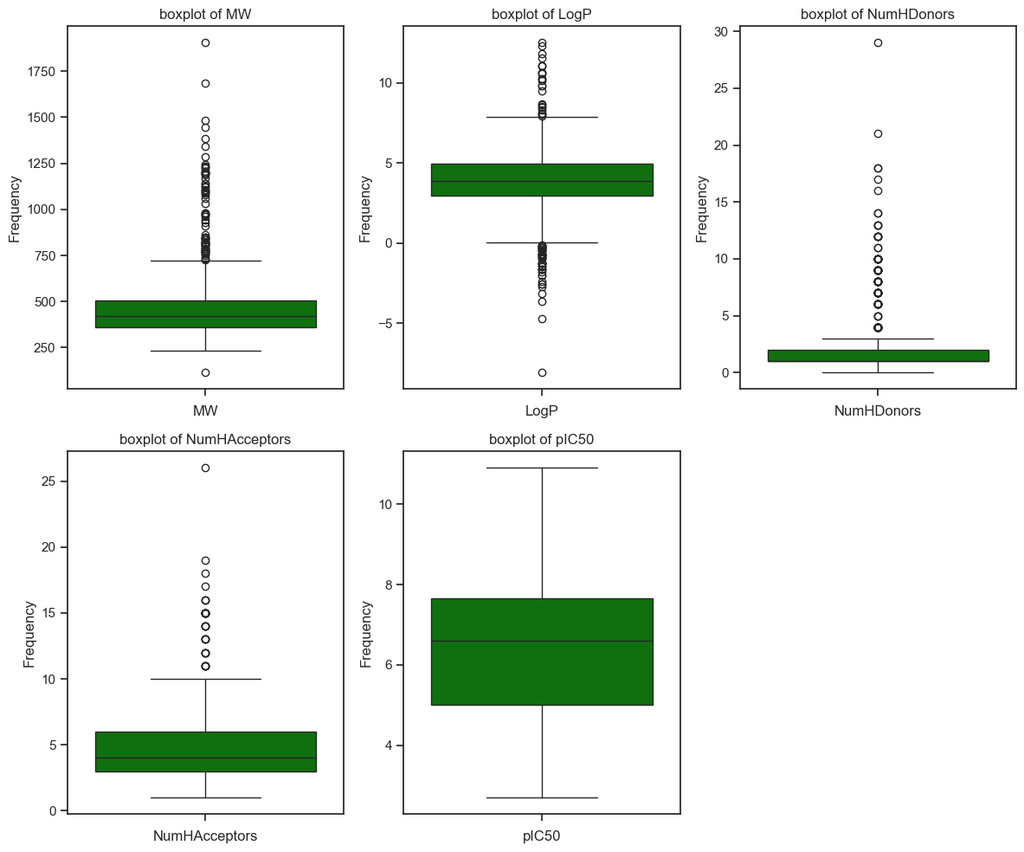

```python
plt.figure(figsize=(12, 10))
numeric_columns = ['MW', 'LogP', 'NumHDonors', 'NumHAcceptors', 'pIC50']
for i, column in enumerate(numeric_columns, 1):
 plt.subplot(2, 3, i) # 2 rows and 3 columns for better layout
 sns.boxplot(df_2class[column],color='green') # kde=True for kernel density estimate
 plt.title(f'boxplot of {column}')
 plt.xlabel(column)
 plt.ylabel('Frequency')
plt.tight_layout()
plt.show()
```

#### Frequency of Bioactivity Classes

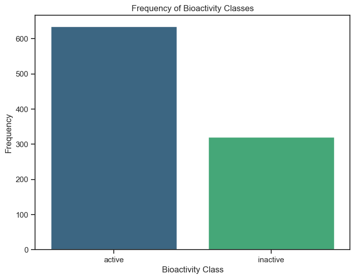

```python
# Set figure size
plt.figure(figsize=(8, 6))
# Count plot with hue
sns.countplot(x='class', hue='class', data=df_2class, palette='viridis')
# Add labels and title
plt.xlabel('Bioactivity Class')
plt.ylabel('Frequency')
plt.title('Frequency of Bioactivity Classes')
# Show plot
plt.show()
```

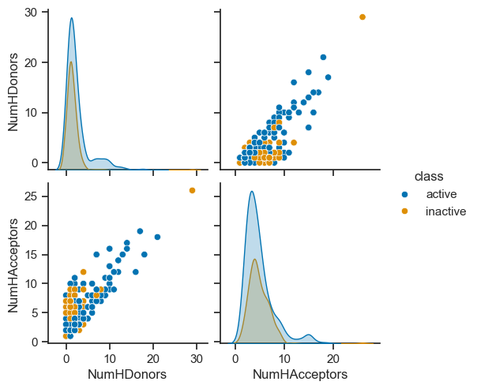

```python
sns.pairplot(df_2class, vars=['NumHDonors', 'NumHAcceptors'], hue='class', palette='colorblind')
# Show plot
plt.show()
```

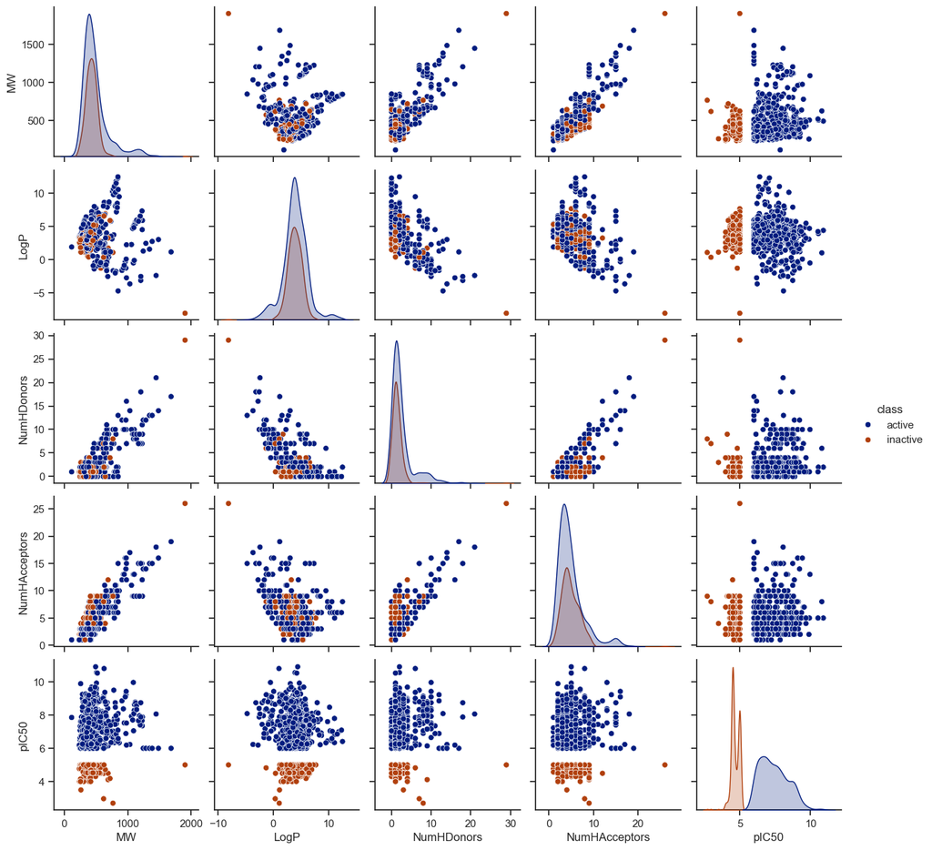

```python
sns.pairplot(df_2class, hue='class', palette='dark')
# Show plot
plt.show()
```

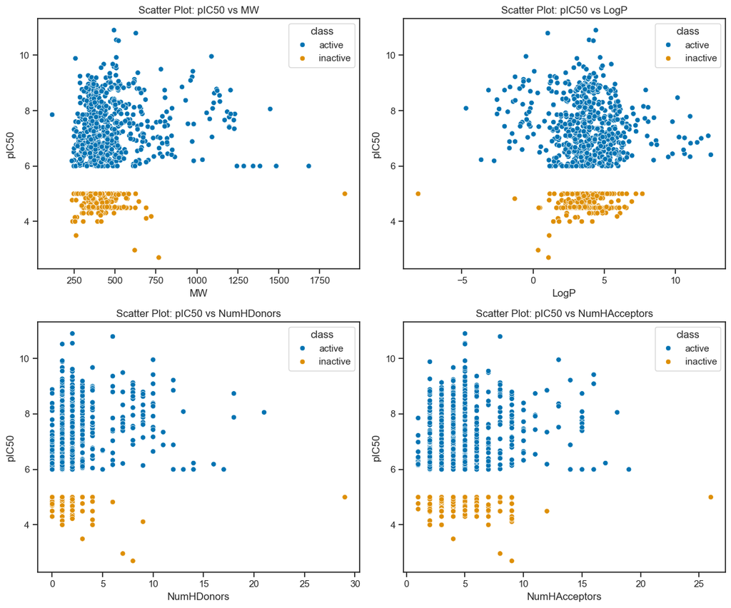

```python
numeric_columns = ['MW', 'LogP', 'NumHDonors', 'NumHAcceptors']
# Set figure size
plt.figure(figsize=(12, 10))
# Loop through numeric columns and create scatter plots
for i, column in enumerate(numeric_columns, 1):
 plt.subplot(2, 2, i) # 2 rows, 2 columns layout
 sns.scatterplot(x=df_2class[column], y=df_2class['pIC50'], hue=df_2class['class'], palette='colorblind')
 plt.title(f'Scatter Plot: pIC50 vs {column}')
 plt.xlabel(column)
 plt.ylabel('pIC50')
# Adjust layout
plt.tight_layout()
plt.show()
```

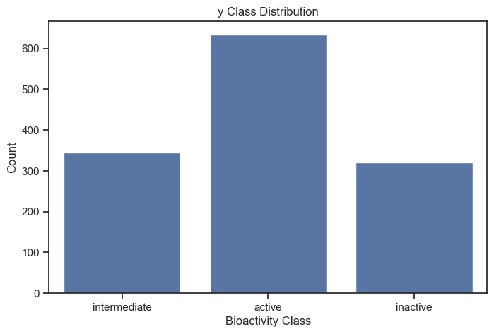

```python
plt.figure(figsize=(8, 5))
sns.countplot(x="class", data=df, )
plt.xlabel("Bioactivity Class")
plt.ylabel("Count")
plt.title("y Class Distribution")
plt.show()
```

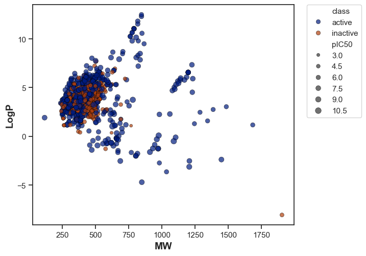

```python
plt.figure(figsize=(6.6, 5.6))
sns.scatterplot(x='MW', y='LogP', data=df_2class, hue='class', size='pIC50',palette='dark', edgecolor='black', alpha=0.7)
plt.xlabel('MW', fontsize=14, fontweight='bold')
plt.ylabel('LogP', fontsize=14, fontweight='bold')
plt.legend(bbox_to_anchor=(1.05, 1), loc=2, borderaxespad=0)
plt.show()
```

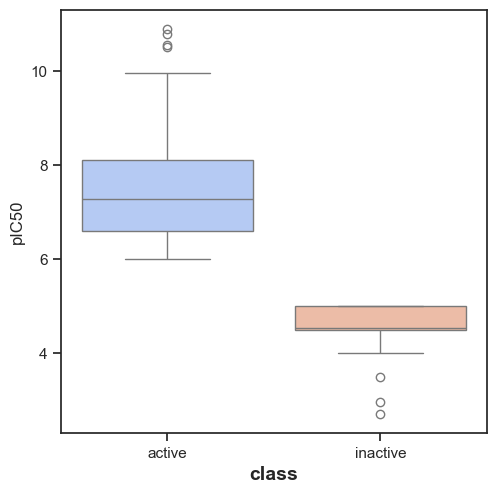

```python
plt.figure(figsize=(5.5, 5.5))
sns.boxplot(x = 'class', y = 'pIC50', data = df_2class, hue = 'class' ,palette = 'coolwarm')
plt.xlabel('class', fontsize=14, fontweight='bold')
```

### Statistical analysis | Mann-Whitney U Test

```python
 # https://machinelearningmastery.com/nonparametric-statistical-significance-tests-in-python/
from numpy.random import seed
from scipy.stats import mannwhitneyu

def mannwhitney(descriptor, verbose=False):
    # Seed the random number generator for reproducibility
    seed(1)

    # Select relevant columns
    selection = [descriptor, 'class']
    df = df_2class[selection]

    # Split active and inactive classes
    active = df[df['class'] == 'active'][descriptor]
    inactive = df[df['class'] == 'inactive'][descriptor]

    # Perform Mann-Whitney U test
    stat, p = mannwhitneyu(active, inactive)

    # Interpret the result
    alpha = 0.05
    interpretation = 'Same distribution (fail to reject H0)' if p > alpha else 'Different distribution (reject H0)'

    # Store results in a DataFrame
    results = pd.DataFrame({
        'Descriptor': [descriptor],
        'Statistics': [stat],
        'p': [p],
        'alpha': [alpha],
        'Interpretation': [interpretation]
    })

    # Save results to CSV
    filename = f'mannwhitneyu_{descriptor}.csv'
    results.to_csv(filename, index=False)

    return results
```

```python
mannwhitney('pIC50')
```

|  | Descriptor | Statistics | p | alpha | Interpretation |
| --- | --- | --- | --- | --- | --- |
| 0 | pIC50 | NaN | NaN | 0.05 | Different distribution (reject H0) |

### MW

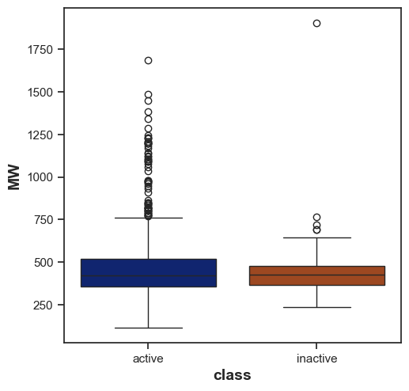

```python
plt.figure(figsize=(5.5, 5.5))
sns.boxplot(x = 'class', y = 'MW', data = df_2class,hue = 'class' , palette = 'dark')
plt.xlabel('class', fontsize=14, fontweight='bold')
plt.ylabel('MW', fontsize=14, fontweight='bold')
```

```python
mannwhitney('MW')
```

|  | Descriptor | Statistics | p | alpha | Interpretation |
| --- | --- | --- | --- | --- | --- |
| 0 | MW | 108504.0 | 0.102365 | 0.05 | Same distribution (fail to reject H0) |

### LogP

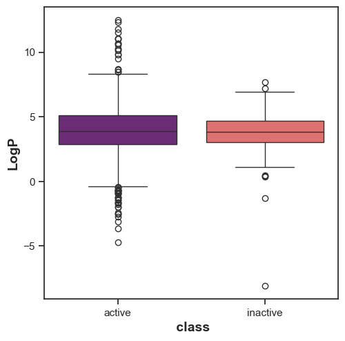

```python
plt.figure(figsize=(5.5, 5.5))

sns.boxplot(x = 'class', y = 'LogP', data = df_2class,hue = 'class' , palette = 'magma')

plt.xlabel(' class', fontsize=14, fontweight='bold')
plt.ylabel('LogP', fontsize=14, fontweight='bold')
```

Statistical analysis | Mann-Whitney U Test

```python
mannwhitney('LogP')
```

|  | Descriptor | Statistics | p | alpha | Interpretation |
| --- | --- | --- | --- | --- | --- |
| 0 | LogP | 105271.5 | 0.405549 | 0.05 | Same distribution (fail to reject H0) |

## NumHDonors

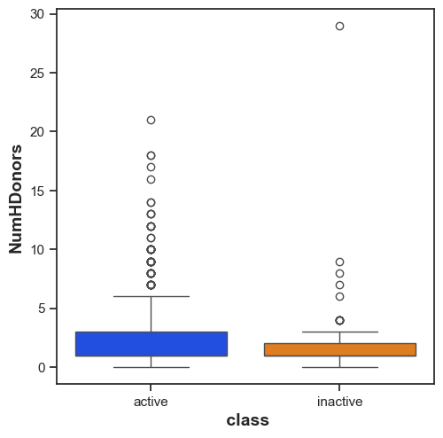

```python
plt.figure(figsize=(5.5, 5.5))
plt.figure(figsize=(5.5, 5.5))
sns.boxplot(x = 'class', y = 'NumHDonors', data = df_2class,hue = 'class' , palette = 'bright')
plt.xlabel(' class', fontsize=14, fontweight='bold')
plt.ylabel('NumHDonors', fontsize=14, fontweight='bold')
```

Statistical analysis | Mann-Whitney U Test

```python
mannwhitney('NumHDonors')
```

|  | Descriptor | Statistics | p | alpha | Interpretation |
| --- | --- | --- | --- | --- | --- |
| 0 | NumHDonors | 123067.0 | 4.233636e-08 | 0.05 | Different distribution (reject H0) |

## NumHAcceptors

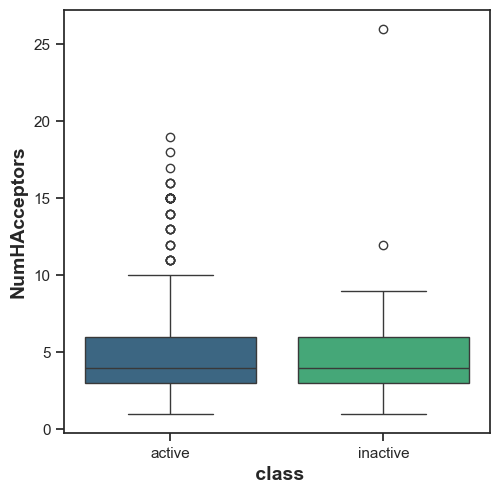

```python
plt.figure(figsize=(5.5, 5.5))

sns.boxplot(x = 'class', y = 'NumHAcceptors', data = df_2class,hue = 'class' , palette = 'viridis')

plt.xlabel(' class', fontsize=14, fontweight='bold')
plt.ylabel('NumHAcceptors', fontsize=14, fontweight='bold')
```

Statistical analysis | Mann-Whitney U Test

```python
mannwhitney('NumHAcceptors')
```

|  | Descriptor | Statistics | p | alpha | Interpretation |
| --- | --- | --- | --- | --- | --- |
| 0 | NumHAcceptors | 91430.0 | 0.008387 | 0.05 | Different distribution (reject H0) |

Box Plots pIC50 values Taking a look at pIC50 values, the actives and inactives displayed statistically significant difference, which is to be expected since threshold values (IC50 < 1,000 nM = Actives while IC50 > 10,000 nM = Inactives, corresponding to pIC50 > 6 = Actives and pIC50 < 5 = Inactives) were used to define actives and inactives.

Lipinski's descriptors Of the 4 Lipinski's descriptors (MW, LogP, NumHDonors and NumHAcceptors), only NumHDonors and NumHAcceptors exhibited difference between the actives and inactives while the other descriptors ( only (MW, LogP shows statistically significant same difference between actives and inactives.

```python
df3 = pd.read_csv(r"C:\Users\manoj\OneDrive\Desktop\opioid receptor\opioid receptor_04_bioactivity_data_3class_pIC50.csv")
```

```python
df3
```

|  | Unnamed: 0 | molecule_chembl_id | canonical_smiles | class | MW | LogP | NumHDonors | NumHAcceptors | pIC50 |
| --- | --- | --- | --- | --- | --- | --- | --- | --- | --- |
| 0 | 2 | CHEMBL13470 | C=CCN1C[C@H](C)N([C@H](c2ccc(C(=O)N(CC)CC)cc2)... | active | 449.639 | 4.84720 | 0.0 | 4.0 | 6.494850 |
| 1 | 4 | CHEMBL126946 | CCN(CC)C(=O)c1ccc(C(=C2CCNCC2)c2ccc(F)cc2)cc1 | inactive | 366.480 | 4.49300 | 1.0 | 2.0 | 5.000000 |
| 2 | 8 | CHEMBL338089 | CCN(CC)C(=O)c1ccc(C(=C2CCN(c3ccccc3)CC2)c2cccc... | inactive | 424.588 | 6.27090 | 0.0 | 2.0 | 5.000000 |
| 3 | 11 | CHEMBL126842 | CCN(CC)C(=O)c1ccc(C(=C2CCN(C)CC2)c2ccccc2)cc1 | inactive | 362.517 | 4.69610 | 0.0 | 2.0 | 5.000000 |
| 4 | 17 | CHEMBL129034 | CCN(CC)C(=O)c1ccc(C(=C2CCNCC2)c2cccc3ccccc23)cc1 | active | 398.550 | 5.50710 | 1.0 | 2.0 | 6.087778 |
| ... | ... | ... | ... | ... | ... | ... | ... | ... | ... |
| 951 | 1296 | CHEMBL5429557 | CN(C)[C@H](CNC(=O)[C@H]1C[C@]1(C)c1ccccc1)Cc1c... | active | 352.478 | 2.95890 | 2.0 | 3.0 | 6.677781 |
| 952 | 1297 | CHEMBL5397104 | CN(C)[C@H](CNC(=O)[C@@H]1C[C@]1(C)c1ccccc1)Cc1... | active | 352.478 | 2.95890 | 2.0 | 3.0 | 6.958607 |
| 953 | 1298 | CHEMBL5414957 | CN(C)[C@H](CNC(=O)[C@@H]1C[C@]1(C)c1ccccc1)Cc1... | active | 386.923 | 3.61230 | 2.0 | 3.0 | 7.537602 |
| 954 | 1299 | CHEMBL2017291 | COc1cc2c(cc1-c1c(C)noc1C)ncc1[nH]c(=O)n([C@H](... | inactive | 415.453 | 4.16254 | 1.0 | 7.0 | 4.000000 |
| 955 | 1300 | CHEMBL3643413 | CCC(=O)N1CC[C@H](Nc2ncnc3c2CN(c2cnc(OC)c(C(F)(... | inactive | 450.465 | 2.88450 | 1.0 | 7.0 | 4.522879 |

956 rows × 9 columns

```python
df3.head()
```

|  | Unnamed: 0 | molecule_chembl_id | canonical_smiles | class | MW | LogP | NumHDonors | NumHAcceptors | pIC50 |
| --- | --- | --- | --- | --- | --- | --- | --- | --- | --- |
| 0 | 2 | CHEMBL13470 | C=CCN1C[C@H](C)N([C@H](c2ccc(C(=O)N(CC)CC)cc2)... | active | 449.639 | 4.8472 | 0.0 | 4.0 | 6.494850 |
| 1 | 4 | CHEMBL126946 | CCN(CC)C(=O)c1ccc(C(=C2CCNCC2)c2ccc(F)cc2)cc1 | inactive | 366.480 | 4.4930 | 1.0 | 2.0 | 5.000000 |
| 2 | 8 | CHEMBL338089 | CCN(CC)C(=O)c1ccc(C(=C2CCN(c3ccccc3)CC2)c2cccc... | inactive | 424.588 | 6.2709 | 0.0 | 2.0 | 5.000000 |
| 3 | 11 | CHEMBL126842 | CCN(CC)C(=O)c1ccc(C(=C2CCN(C)CC2)c2ccccc2)cc1 | inactive | 362.517 | 4.6961 | 0.0 | 2.0 | 5.000000 |
| 4 | 17 | CHEMBL129034 | CCN(CC)C(=O)c1ccc(C(=C2CCNCC2)c2cccc3ccccc23)cc1 | active | 398.550 | 5.5071 | 1.0 | 2.0 | 6.087778 |

```python
df3.describe()
```

|  | Unnamed: 0 | MW | LogP | NumHDonors | NumHAcceptors | pIC50 |
| --- | --- | --- | --- | --- | --- | --- |
| count | 956.000000 | 956.000000 | 956.000000 | 956.000000 | 956.000000 | 955.000000 |
| mean | 677.293933 | 468.168969 | 3.875962 | 2.146444 | 4.843096 | 6.481876 |
| std | 364.371668 | 190.384243 | 2.008802 | 2.721929 | 2.745861 | 1.539089 |
| min | 2.000000 | 115.220000 | -8.073000 | 0.000000 | 1.000000 | 2.698970 |
| 25% | 388.250000 | 362.469250 | 2.958900 | 1.000000 | 3.000000 | 5.000000 |
| 50% | 678.000000 | 423.794500 | 3.868980 | 1.000000 | 4.000000 | 6.596879 |
| 75% | 998.250000 | 507.030000 | 4.937450 | 2.000000 | 6.000000 | 7.657577 |
| max | 1300.000000 | 1904.213000 | 12.487600 | 29.000000 | 26.000000 | 10.903090 |

```python
selection = ['canonical_smiles','molecule_chembl_id']
df3_selection = df3[selection]
df3_selection.to_csv('molecule.smi', sep='\t', index=False, header=False)
```

```python
with open('molecule.smi', 'r') as file:
 for _ in range(5):
     print(file.readline().strip())
```

```
C=CCN1C[C@H](C)N([C@H](c2ccc(C(=O)N(CC)CC)cc2)c2cccc(OC)c2)C[C@H]1C	CHEMBL13470
CCN(CC)C(=O)c1ccc(C(=C2CCNCC2)c2ccc(F)cc2)cc1	CHEMBL126946
CCN(CC)C(=O)c1ccc(C(=C2CCN(c3ccccc3)CC2)c2ccccc2)cc1	CHEMBL338089
CCN(CC)C(=O)c1ccc(C(=C2CCN(C)CC2)c2ccccc2)cc1	CHEMBL126842
CCN(CC)C(=O)c1ccc(C(=C2CCNCC2)c2cccc3ccccc23)cc1	CHEMBL129034
```

```python
with open('molecule.smi', 'r') as file:
 line_count = sum(1 for line in file)
print("Total number of lines:", line_count)
```

```
Total number of lines: 956
```

## Preparing the X and Y Data Matrices

```python
X = pd.read_csv(r"C:\Users\manoj\OneDrive\Desktop\New folder\archive\descriptors_output.csv")
```

```python
X
```

|  | Name | PubchemFP0 | PubchemFP1 | PubchemFP2 | PubchemFP3 | PubchemFP4 | PubchemFP5 | PubchemFP6 | PubchemFP7 | PubchemFP8 | ... | PubchemFP871 | PubchemFP872 | PubchemFP873 | PubchemFP874 | PubchemFP875 | PubchemFP876 | PubchemFP877 | PubchemFP878 | PubchemFP879 | PubchemFP880 |
| --- | --- | --- | --- | --- | --- | --- | --- | --- | --- | --- | --- | --- | --- | --- | --- | --- | --- | --- | --- | --- | --- |
| 0 | CHEMBL130478 | 1 | 1 | 0 | 0 | 0 | 0 | 0 | 0 | 0 | ... | 0 | 0 | 0 | 0 | 0 | 0 | 0 | 0 | 0 | 0 |
| 1 | CHEMBL336538 | 1 | 1 | 1 | 0 | 0 | 0 | 0 | 0 | 0 | ... | 0 | 0 | 0 | 0 | 0 | 0 | 0 | 0 | 0 | 0 |
| 2 | CHEMBL339995 | 1 | 1 | 1 | 0 | 0 | 0 | 0 | 0 | 0 | ... | 0 | 0 | 0 | 0 | 0 | 0 | 0 | 0 | 0 | 0 |
| 3 | CHEMBL341437 | 1 | 1 | 1 | 0 | 0 | 0 | 0 | 0 | 0 | ... | 0 | 0 | 0 | 0 | 0 | 0 | 0 | 0 | 0 | 0 |
| 4 | CHEMBL130098 | 1 | 1 | 0 | 0 | 0 | 0 | 0 | 0 | 0 | ... | 0 | 0 | 0 | 0 | 0 | 0 | 0 | 0 | 0 | 0 |
| ... | ... | ... | ... | ... | ... | ... | ... | ... | ... | ... | ... | ... | ... | ... | ... | ... | ... | ... | ... | ... | ... |
| 6941 | CHEMBL253998 | 1 | 1 | 1 | 0 | 0 | 0 | 0 | 0 | 0 | ... | 0 | 0 | 0 | 0 | 0 | 0 | 0 | 0 | 0 | 0 |
| 6942 | CHEMBL502 | 1 | 1 | 1 | 0 | 0 | 0 | 0 | 0 | 0 | ... | 0 | 0 | 0 | 0 | 0 | 0 | 0 | 0 | 0 | 0 |
| 6943 | CHEMBL3085398 | 1 | 1 | 1 | 0 | 0 | 0 | 0 | 0 | 0 | ... | 0 | 0 | 0 | 0 | 0 | 0 | 0 | 0 | 0 | 0 |
| 6944 | CHEMBL13045 | 1 | 1 | 1 | 0 | 0 | 0 | 0 | 0 | 0 | ... | 0 | 0 | 0 | 0 | 0 | 0 | 0 | 0 | 0 | 0 |
| 6945 | CHEMBL417799 | 1 | 1 | 0 | 0 | 0 | 0 | 0 | 0 | 0 | ... | 0 | 0 | 0 | 0 | 0 | 0 | 0 | 0 | 0 | 0 |

6946 rows × 882 columns

```python
X.head()
```

|  | Name | PubchemFP0 | PubchemFP1 | PubchemFP2 | PubchemFP3 | PubchemFP4 | PubchemFP5 | PubchemFP6 | PubchemFP7 | PubchemFP8 | ... | PubchemFP871 | PubchemFP872 | PubchemFP873 | PubchemFP874 | PubchemFP875 | PubchemFP876 | PubchemFP877 | PubchemFP878 | PubchemFP879 | PubchemFP880 |
| --- | --- | --- | --- | --- | --- | --- | --- | --- | --- | --- | --- | --- | --- | --- | --- | --- | --- | --- | --- | --- | --- |
| 0 | CHEMBL130478 | 1 | 1 | 0 | 0 | 0 | 0 | 0 | 0 | 0 | ... | 0 | 0 | 0 | 0 | 0 | 0 | 0 | 0 | 0 | 0 |
| 1 | CHEMBL336538 | 1 | 1 | 1 | 0 | 0 | 0 | 0 | 0 | 0 | ... | 0 | 0 | 0 | 0 | 0 | 0 | 0 | 0 | 0 | 0 |
| 2 | CHEMBL339995 | 1 | 1 | 1 | 0 | 0 | 0 | 0 | 0 | 0 | ... | 0 | 0 | 0 | 0 | 0 | 0 | 0 | 0 | 0 | 0 |
| 3 | CHEMBL341437 | 1 | 1 | 1 | 0 | 0 | 0 | 0 | 0 | 0 | ... | 0 | 0 | 0 | 0 | 0 | 0 | 0 | 0 | 0 | 0 |
| 4 | CHEMBL130098 | 1 | 1 | 0 | 0 | 0 | 0 | 0 | 0 | 0 | ... | 0 | 0 | 0 | 0 | 0 | 0 | 0 | 0 | 0 | 0 |

5 rows × 882 columns

```python
X.info()
```

```
<class 'pandas.core.frame.DataFrame'>
RangeIndex: 6946 entries, 0 to 6945
Columns: 882 entries, Name to PubchemFP880
dtypes: int64(881), object(1)
memory usage: 46.7+ MB
```

```python
X.dtypes
```

```
Name            object
PubchemFP0       int64
PubchemFP1       int64
PubchemFP2       int64
PubchemFP3       int64
                 ...
PubchemFP876     int64
PubchemFP877     int64
PubchemFP878     int64
PubchemFP879     int64
PubchemFP880     int64
Length: 882, dtype: object
```

```python
X = X.drop(columns=['Name'])
X
```

|  | PubchemFP0 | PubchemFP1 | PubchemFP2 | PubchemFP3 | PubchemFP4 | PubchemFP5 | PubchemFP6 | PubchemFP7 | PubchemFP8 | PubchemFP9 | ... | PubchemFP871 | PubchemFP872 | PubchemFP873 | PubchemFP874 | PubchemFP875 | PubchemFP876 | PubchemFP877 | PubchemFP878 | PubchemFP879 | PubchemFP880 |
| --- | --- | --- | --- | --- | --- | --- | --- | --- | --- | --- | --- | --- | --- | --- | --- | --- | --- | --- | --- | --- | --- |
| 0 | 1 | 1 | 0 | 0 | 0 | 0 | 0 | 0 | 0 | 1 | ... | 0 | 0 | 0 | 0 | 0 | 0 | 0 | 0 | 0 | 0 |
| 1 | 1 | 1 | 1 | 0 | 0 | 0 | 0 | 0 | 0 | 1 | ... | 0 | 0 | 0 | 0 | 0 | 0 | 0 | 0 | 0 | 0 |
| 2 | 1 | 1 | 1 | 0 | 0 | 0 | 0 | 0 | 0 | 1 | ... | 0 | 0 | 0 | 0 | 0 | 0 | 0 | 0 | 0 | 0 |
| 3 | 1 | 1 | 1 | 0 | 0 | 0 | 0 | 0 | 0 | 1 | ... | 0 | 0 | 0 | 0 | 0 | 0 | 0 | 0 | 0 | 0 |
| 4 | 1 | 1 | 0 | 0 | 0 | 0 | 0 | 0 | 0 | 1 | ... | 0 | 0 | 0 | 0 | 0 | 0 | 0 | 0 | 0 | 0 |
| ... | ... | ... | ... | ... | ... | ... | ... | ... | ... | ... | ... | ... | ... | ... | ... | ... | ... | ... | ... | ... | ... |
| 6941 | 1 | 1 | 1 | 0 | 0 | 0 | 0 | 0 | 0 | 1 | ... | 0 | 0 | 0 | 0 | 0 | 0 | 0 | 0 | 0 | 0 |
| 6942 | 1 | 1 | 1 | 0 | 0 | 0 | 0 | 0 | 0 | 1 | ... | 0 | 0 | 0 | 0 | 0 | 0 | 0 | 0 | 0 | 0 |
| 6943 | 1 | 1 | 1 | 0 | 0 | 0 | 0 | 0 | 0 | 1 | ... | 0 | 0 | 0 | 0 | 0 | 0 | 0 | 0 | 0 | 0 |
| 6944 | 1 | 1 | 1 | 0 | 0 | 0 | 0 | 0 | 0 | 1 | ... | 0 | 0 | 0 | 0 | 0 | 0 | 0 | 0 | 0 | 0 |
| 6945 | 1 | 1 | 0 | 0 | 0 | 0 | 0 | 0 | 0 | 1 | ... | 0 | 0 | 0 | 0 | 0 | 0 | 0 | 0 | 0 | 0 |

6946 rows × 881 columns

## Y variable

```python
y = df3['class']
```

```python
y = y.map({'active': 1, 'inactive': 0})
```

## Split dataset

```python
print("Shape of X:", X.shape)
print("Shape of y:", y.shape)
```

```
Shape of X: (6946, 881)
Shape of y: (956,)
```

```python
X = X.iloc[:y.shape[0], :]  # Trim X to match y
```

```python
print("Shape of X:", X.shape)
print("Shape of y:", y.shape)
```

```
Shape of X: (956, 881)
Shape of y: (956,)
```

```python
from sklearn.model_selection import train_test_split
X_train, X_test, y_train, y_test = train_test_split(X, y, test_size=0.3, random_state=42)
```

```python
from sklearn.preprocessing import StandardScaler
from sklearn.ensemble import RandomForestClassifier
from sklearn.svm import SVC
from sklearn.linear_model import LogisticRegression
from sklearn.metrics import accuracy_score, classification_report, confusion_matrix
```

```python
scaler = StandardScaler()
X_train_scaled = scaler.fit_transform(X_train)
X_test_scaled = scaler.transform(X_test)
```

## Logistic Regression Model

```python
lr = LogisticRegression(max_iter=600)
```

```python
lr.fit(X_train, y_train)
```

```
LogisticRegression(max_iter=600)
```

```python
y_pred_lr = lr.predict(X_test)
y_pred_lr
```

```
array([1, 1, 0, 0, 1, 1, 1, 1, 1, 1, 0, 1, 0, 0, 0, 1, 0, 1, 1, 1, 1, 1,
       1, 0, 0, 1, 1, 1, 1, 1, 0, 1, 0, 1, 1, 1, 1, 1, 0, 1, 0, 1, 1, 1,
       0, 1, 1, 1, 1, 1, 1, 1, 1, 1, 1, 0, 1, 1, 1, 1, 1, 1, 1, 1, 1, 1,
       1, 1, 1, 1, 1, 1, 1, 1, 1, 0, 1, 1, 1, 1, 1, 0, 0, 1, 1, 1, 1, 1,
       1, 1, 1, 1, 1, 1, 1, 1, 1, 1, 0, 1, 0, 1, 0, 1, 1, 1, 0, 1, 1, 1,
       1, 1, 1, 1, 1, 1, 1, 1, 1, 1, 1, 0, 1, 1, 1, 1, 1, 1, 0, 0, 0, 1,
       1, 1, 1, 1, 1, 1, 1, 1, 1, 0, 1, 1, 1, 1, 1, 1, 1, 1, 1, 1, 1, 0,
       1, 1, 1, 1, 1, 0, 1, 1, 1, 1, 0, 1, 1, 1, 1, 1, 1, 0, 0, 1, 1, 1,
       1, 1, 1, 1, 1, 1, 1, 1, 1, 0, 1, 0, 1, 1, 1, 1, 1, 1, 1, 1, 1, 1,
       0, 1, 1, 1, 1, 1, 1, 1, 0, 1, 0, 0, 1, 0, 1, 1, 1, 1, 1, 1, 1, 0,
       1, 1, 1, 1, 0, 1, 1, 1, 1, 0, 1, 1, 1, 0, 0, 1, 1, 1, 1, 1, 1, 0,
       1, 1, 1, 1, 1, 1, 1, 1, 1, 1, 1, 1, 1, 1, 1, 1, 0, 1, 1, 1, 1, 1,
       1, 1, 1, 1, 1, 1, 0, 1, 0, 1, 1, 0, 0, 1, 1, 1, 1, 0, 0, 1, 1, 1,
       1], dtype=int64)
```

```python
print(classification_report(y_test, y_pred_lr))
```

```
              precision    recall  f1-score   support

           0       0.63      0.33      0.44        99
           1       0.72      0.90      0.80       188

    accuracy                           0.70       287
   macro avg       0.68      0.62      0.62       287
weighted avg       0.69      0.70      0.67       287
```

```python
accuracy = accuracy_score(y_test, y_pred_lr)
print(f"Logistic Regression Model Accuracy: {accuracy * 100:.2f}%")
```

```
Logistic Regression Model Accuracy: 70.38%
```

```
[Text(0, 0.5, 'targeted_label_1'), Text(0, 1.5, 'targeted_label_2')]
```

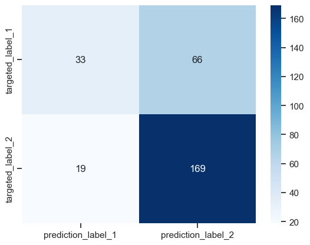

```python
cm = confusion_matrix(y_test, y_pred_lr)
ax = sns.heatmap(cm, annot=True, fmt='d', cmap="Blues")
ax.xaxis.set_ticklabels(['prediction_label_1', 'prediction_label_2' ])
ax.yaxis.set_ticklabels(['targeted_label_1', 'targeted_label_2' ])
```

## Logistic Regression Model Accuracy: 70.38%

```python
from sklearn.tree import DecisionTreeClassifier
DT = DecisionTreeClassifier()
DT.fit(X_train,y_train)
```

```
DecisionTreeClassifier()
```

```python
y_pred_DT = DT.predict(X_test)
y_pred_DT
```

```
array([1, 1, 0, 0, 1, 1, 0, 1, 1, 1, 1, 1, 1, 0, 0, 1, 0, 0, 1, 0, 1, 1,
       1, 0, 0, 0, 1, 1, 0, 1, 0, 1, 0, 1, 1, 1, 0, 1, 0, 1, 0, 1, 1, 1,
       0, 0, 1, 0, 0, 1, 1, 0, 1, 0, 1, 1, 1, 1, 1, 0, 1, 1, 0, 1, 1, 1,
       0, 1, 0, 1, 1, 1, 1, 1, 0, 0, 1, 1, 0, 1, 1, 0, 1, 1, 1, 1, 1, 1,
       1, 1, 1, 0, 1, 1, 1, 1, 1, 1, 0, 1, 1, 1, 0, 0, 1, 0, 0, 1, 1, 0,
       0, 0, 1, 1, 1, 1, 1, 1, 0, 1, 1, 0, 1, 0, 1, 1, 1, 1, 0, 0, 0, 1,
       1, 1, 1, 1, 1, 1, 1, 0, 1, 0, 1, 1, 1, 1, 0, 0, 1, 1, 1, 1, 0, 0,
       1, 0, 1, 1, 0, 0, 1, 1, 0, 1, 0, 1, 1, 1, 1, 1, 1, 0, 1, 1, 0, 1,
       1, 0, 0, 1, 1, 1, 0, 1, 1, 0, 0, 0, 1, 1, 1, 1, 0, 1, 0, 1, 1, 1,
       0, 1, 1, 1, 1, 1, 0, 1, 1, 1, 0, 0, 0, 1, 0, 1, 1, 1, 1, 0, 1, 0,
       1, 1, 1, 0, 0, 1, 1, 0, 1, 1, 1, 1, 1, 0, 0, 0, 1, 1, 1, 0, 1, 0,
       1, 1, 1, 1, 1, 0, 1, 1, 1, 1, 0, 1, 1, 1, 1, 1, 0, 1, 1, 1, 1, 1,
       0, 1, 1, 1, 1, 1, 0, 1, 0, 1, 0, 0, 1, 1, 0, 1, 1, 0, 0, 1, 1, 1,
       1], dtype=int64)
```

```python
print(classification_report(y_test,y_pred_DT))
```

```
              precision    recall  f1-score   support

           0       0.55      0.53      0.54        99
           1       0.76      0.78      0.77       188

    accuracy                           0.69       287
   macro avg       0.65      0.65      0.65       287
weighted avg       0.69      0.69      0.69       287
```

```python
accuracy = accuracy_score(y_test, y_pred_DT)
print(f"DecisionTreeClassifier Model Accuracy: {accuracy * 100:.2f}%")
```

```
DecisionTreeClassifier Model Accuracy: 68.99%
```

```
[Text(0, 0.5, 'targeted_label_1'), Text(0, 1.5, 'targeted_label_2')]
```

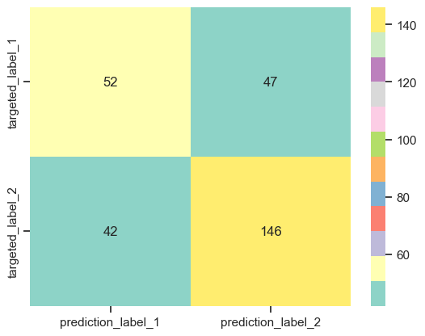

```python
cm = confusion_matrix(y_test, y_pred_DT)
ax = sns.heatmap(cm, annot=True, fmt='d', cmap="Set3")
ax.xaxis.set_ticklabels(['prediction_label_1', 'prediction_label_2' ])
ax.yaxis.set_ticklabels(['targeted_label_1', 'targeted_label_2' ])
```

## DecisionTreeClassifier Model Accuracy: 68.99%

## RandomForestClassifier

```python
rnf = RandomForestClassifier()
rnf.fit(X_train,y_train)
```

```
RandomForestClassifier()
```

```python
y_pred_rnf = rnf.predict(X_test)
y_pred_rnf
```

```
array([1, 1, 0, 0, 1, 1, 0, 1, 1, 1, 0, 1, 0, 0, 0, 1, 0, 1, 1, 0, 1, 1,
       1, 0, 0, 1, 1, 1, 1, 1, 0, 1, 0, 1, 1, 1, 0, 1, 0, 1, 0, 1, 1, 1,
       0, 1, 1, 0, 1, 1, 1, 1, 1, 0, 1, 1, 1, 1, 1, 0, 1, 1, 1, 1, 1, 1,
       1, 1, 0, 1, 1, 1, 1, 1, 1, 0, 1, 1, 0, 1, 1, 0, 1, 1, 1, 1, 1, 1,
       1, 1, 1, 1, 1, 1, 1, 1, 1, 1, 0, 1, 1, 1, 0, 1, 1, 0, 0, 1, 1, 1,
       0, 0, 1, 1, 1, 1, 1, 1, 0, 1, 1, 0, 1, 0, 1, 1, 1, 1, 0, 0, 1, 1,
       1, 1, 1, 1, 1, 1, 1, 0, 1, 0, 1, 1, 1, 1, 0, 1, 1, 1, 1, 1, 0, 0,
       1, 1, 1, 1, 1, 0, 1, 0, 0, 1, 0, 1, 1, 1, 1, 1, 1, 0, 1, 1, 0, 1,
       1, 0, 0, 1, 1, 1, 1, 1, 1, 1, 1, 0, 1, 1, 1, 1, 0, 1, 0, 1, 1, 1,
       0, 1, 1, 1, 1, 1, 0, 1, 1, 1, 0, 0, 0, 1, 1, 1, 1, 1, 1, 1, 1, 0,
       1, 1, 1, 1, 0, 1, 1, 0, 1, 0, 1, 1, 1, 0, 0, 1, 1, 1, 1, 1, 1, 0,
       1, 1, 1, 1, 1, 0, 1, 1, 1, 1, 1, 1, 1, 1, 0, 1, 0, 1, 1, 1, 1, 1,
       0, 1, 1, 1, 1, 1, 1, 1, 0, 1, 0, 0, 0, 1, 1, 1, 1, 0, 0, 1, 1, 1,
       1], dtype=int64)
```

```python
print(classification_report(y_test,y_pred_rnf))
```

```
              precision    recall  f1-score   support

           0       0.67      0.49      0.57        99
           1       0.77      0.87      0.82       188

    accuracy                           0.74       287
   macro avg       0.72      0.68      0.69       287
weighted avg       0.73      0.74      0.73       287
```

```python
accuracy = accuracy_score(y_test, y_pred_rnf)
print(f"RandomForestClassifier Model Accuracy: {accuracy * 100:.2f}%")
```

```
RandomForestClassifier Model Accuracy: 74.22%
```

```
[Text(0, 0.5, 'targeted_label_1'), Text(0, 1.5, 'targeted_label_2')]
```

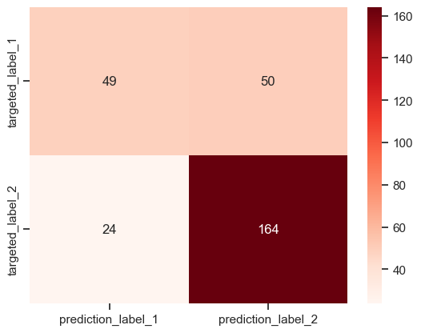

```python
cm = confusion_matrix(y_test, y_pred_rnf)
ax = sns.heatmap(cm, annot=True, fmt='d', cmap="Reds")
ax.xaxis.set_ticklabels(['prediction_label_1', 'prediction_label_2' ])
ax.yaxis.set_ticklabels(['targeted_label_1', 'targeted_label_2' ])
```

## RandomForestClassifier Model Accuracy: 74.22%

## K-Nearest Neighbors (KNN)

```python
from sklearn.neighbors import KNeighborsClassifier
knn = KNeighborsClassifier(n_neighbors=5)
knn.fit(X_train,y_train)
```

```
KNeighborsClassifier()
```

```python
y_pred_knn = knn.predict(X_test)
y_pred_knn
```

```
array([1, 1, 0, 0, 1, 1, 0, 1, 1, 1, 0, 1, 1, 1, 0, 1, 0, 1, 1, 0, 1, 1,
       1, 1, 0, 1, 1, 1, 1, 1, 0, 1, 1, 1, 1, 1, 1, 0, 1, 1, 0, 1, 1, 1,
       0, 1, 1, 0, 1, 1, 1, 1, 1, 0, 1, 1, 1, 1, 1, 1, 1, 1, 1, 1, 1, 0,
       1, 1, 1, 1, 1, 1, 1, 1, 1, 0, 1, 1, 0, 1, 1, 0, 1, 1, 1, 1, 1, 1,
       1, 1, 1, 1, 0, 1, 1, 1, 1, 1, 0, 1, 1, 1, 0, 1, 1, 0, 1, 1, 0, 1,
       0, 0, 1, 0, 1, 1, 1, 1, 1, 1, 1, 0, 1, 0, 1, 1, 1, 1, 0, 0, 1, 1,
       1, 1, 1, 1, 1, 1, 1, 1, 1, 0, 1, 0, 0, 1, 1, 1, 1, 1, 0, 1, 0, 0,
       1, 1, 1, 1, 1, 0, 1, 1, 1, 1, 0, 1, 1, 1, 1, 1, 1, 0, 1, 0, 1, 1,
       1, 1, 1, 1, 1, 1, 1, 1, 1, 0, 1, 0, 1, 1, 1, 1, 1, 1, 1, 1, 1, 1,
       0, 1, 1, 1, 1, 1, 1, 0, 0, 1, 0, 0, 1, 1, 1, 1, 1, 1, 1, 1, 1, 0,
       1, 1, 1, 1, 0, 1, 1, 0, 1, 0, 1, 1, 1, 0, 0, 1, 1, 1, 1, 1, 1, 0,
       1, 0, 1, 1, 1, 1, 1, 1, 1, 1, 1, 1, 1, 1, 0, 0, 1, 1, 1, 1, 1, 1,
       1, 1, 1, 1, 1, 1, 1, 1, 0, 1, 1, 0, 1, 1, 1, 1, 1, 0, 0, 1, 1, 1,
       1], dtype=int64)
```

```python
print(classification_report(y_test,y_pred_knn))
```

```
              precision    recall  f1-score   support

           0       0.66      0.40      0.50        99
           1       0.74      0.89      0.81       188

    accuracy                           0.72       287
   macro avg       0.70      0.65      0.65       287
weighted avg       0.71      0.72      0.70       287
```

```python
accuracy = accuracy_score(y_test, y_pred_knn)
print(f"KNeighborsClassifier Model Accuracy: {accuracy * 100:.2f}%")
```

```
KNeighborsClassifier Model Accuracy: 72.13%
```

```
[Text(0, 0.5, 'targeted_label_1'), Text(0, 1.5, 'targeted_label_2')]
```

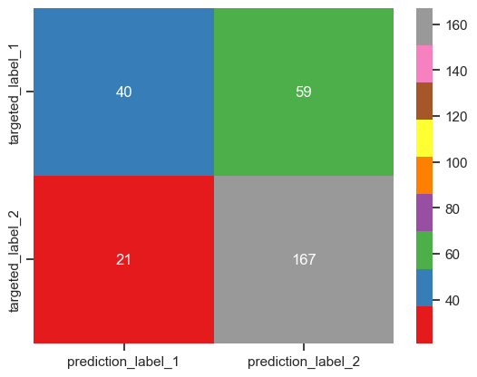

```python
cm = confusion_matrix(y_test, y_pred_knn)
ax = sns.heatmap(cm, annot=True, fmt='d', cmap="Set1")
ax.xaxis.set_ticklabels(['prediction_label_1', 'prediction_label_2' ])
ax.yaxis.set_ticklabels(['targeted_label_1', 'targeted_label_2' ])
```

## KNeighborsClassifier Model Accuracy: 72.13%

```python
df3_X = pd.read_csv(r"C:\Users\manoj\OneDrive\Desktop\New folder\archive\descriptors_output.csv")
```

```python
df3_X
```

|  | Name | PubchemFP0 | PubchemFP1 | PubchemFP2 | PubchemFP3 | PubchemFP4 | PubchemFP5 | PubchemFP6 | PubchemFP7 | PubchemFP8 | ... | PubchemFP871 | PubchemFP872 | PubchemFP873 | PubchemFP874 | PubchemFP875 | PubchemFP876 | PubchemFP877 | PubchemFP878 | PubchemFP879 | PubchemFP880 |
| --- | --- | --- | --- | --- | --- | --- | --- | --- | --- | --- | --- | --- | --- | --- | --- | --- | --- | --- | --- | --- | --- |
| 0 | CHEMBL130478 | 1 | 1 | 0 | 0 | 0 | 0 | 0 | 0 | 0 | ... | 0 | 0 | 0 | 0 | 0 | 0 | 0 | 0 | 0 | 0 |
| 1 | CHEMBL336538 | 1 | 1 | 1 | 0 | 0 | 0 | 0 | 0 | 0 | ... | 0 | 0 | 0 | 0 | 0 | 0 | 0 | 0 | 0 | 0 |
| 2 | CHEMBL339995 | 1 | 1 | 1 | 0 | 0 | 0 | 0 | 0 | 0 | ... | 0 | 0 | 0 | 0 | 0 | 0 | 0 | 0 | 0 | 0 |
| 3 | CHEMBL341437 | 1 | 1 | 1 | 0 | 0 | 0 | 0 | 0 | 0 | ... | 0 | 0 | 0 | 0 | 0 | 0 | 0 | 0 | 0 | 0 |
| 4 | CHEMBL130098 | 1 | 1 | 0 | 0 | 0 | 0 | 0 | 0 | 0 | ... | 0 | 0 | 0 | 0 | 0 | 0 | 0 | 0 | 0 | 0 |
| ... | ... | ... | ... | ... | ... | ... | ... | ... | ... | ... | ... | ... | ... | ... | ... | ... | ... | ... | ... | ... | ... |
| 6941 | CHEMBL253998 | 1 | 1 | 1 | 0 | 0 | 0 | 0 | 0 | 0 | ... | 0 | 0 | 0 | 0 | 0 | 0 | 0 | 0 | 0 | 0 |
| 6942 | CHEMBL502 | 1 | 1 | 1 | 0 | 0 | 0 | 0 | 0 | 0 | ... | 0 | 0 | 0 | 0 | 0 | 0 | 0 | 0 | 0 | 0 |
| 6943 | CHEMBL3085398 | 1 | 1 | 1 | 0 | 0 | 0 | 0 | 0 | 0 | ... | 0 | 0 | 0 | 0 | 0 | 0 | 0 | 0 | 0 | 0 |
| 6944 | CHEMBL13045 | 1 | 1 | 1 | 0 | 0 | 0 | 0 | 0 | 0 | ... | 0 | 0 | 0 | 0 | 0 | 0 | 0 | 0 | 0 | 0 |
| 6945 | CHEMBL417799 | 1 | 1 | 0 | 0 | 0 | 0 | 0 | 0 | 0 | ... | 0 | 0 | 0 | 0 | 0 | 0 | 0 | 0 | 0 | 0 |

6946 rows × 882 columns

```python
df3_X = df3_X.drop(columns=['Name'])
df3_X
```

|  | PubchemFP0 | PubchemFP1 | PubchemFP2 | PubchemFP3 | PubchemFP4 | PubchemFP5 | PubchemFP6 | PubchemFP7 | PubchemFP8 | PubchemFP9 | ... | PubchemFP871 | PubchemFP872 | PubchemFP873 | PubchemFP874 | PubchemFP875 | PubchemFP876 | PubchemFP877 | PubchemFP878 | PubchemFP879 | PubchemFP880 |
| --- | --- | --- | --- | --- | --- | --- | --- | --- | --- | --- | --- | --- | --- | --- | --- | --- | --- | --- | --- | --- | --- |
| 0 | 1 | 1 | 0 | 0 | 0 | 0 | 0 | 0 | 0 | 1 | ... | 0 | 0 | 0 | 0 | 0 | 0 | 0 | 0 | 0 | 0 |
| 1 | 1 | 1 | 1 | 0 | 0 | 0 | 0 | 0 | 0 | 1 | ... | 0 | 0 | 0 | 0 | 0 | 0 | 0 | 0 | 0 | 0 |
| 2 | 1 | 1 | 1 | 0 | 0 | 0 | 0 | 0 | 0 | 1 | ... | 0 | 0 | 0 | 0 | 0 | 0 | 0 | 0 | 0 | 0 |
| 3 | 1 | 1 | 1 | 0 | 0 | 0 | 0 | 0 | 0 | 1 | ... | 0 | 0 | 0 | 0 | 0 | 0 | 0 | 0 | 0 | 0 |
| 4 | 1 | 1 | 0 | 0 | 0 | 0 | 0 | 0 | 0 | 1 | ... | 0 | 0 | 0 | 0 | 0 | 0 | 0 | 0 | 0 | 0 |
| ... | ... | ... | ... | ... | ... | ... | ... | ... | ... | ... | ... | ... | ... | ... | ... | ... | ... | ... | ... | ... | ... |
| 6941 | 1 | 1 | 1 | 0 | 0 | 0 | 0 | 0 | 0 | 1 | ... | 0 | 0 | 0 | 0 | 0 | 0 | 0 | 0 | 0 | 0 |
| 6942 | 1 | 1 | 1 | 0 | 0 | 0 | 0 | 0 | 0 | 1 | ... | 0 | 0 | 0 | 0 | 0 | 0 | 0 | 0 | 0 | 0 |
| 6943 | 1 | 1 | 1 | 0 | 0 | 0 | 0 | 0 | 0 | 1 | ... | 0 | 0 | 0 | 0 | 0 | 0 | 0 | 0 | 0 | 0 |
| 6944 | 1 | 1 | 1 | 0 | 0 | 0 | 0 | 0 | 0 | 1 | ... | 0 | 0 | 0 | 0 | 0 | 0 | 0 | 0 | 0 | 0 |
| 6945 | 1 | 1 | 0 | 0 | 0 | 0 | 0 | 0 | 0 | 1 | ... | 0 | 0 | 0 | 0 | 0 | 0 | 0 | 0 | 0 | 0 |

6946 rows × 881 columns

```python
Y = df3['pIC50']
Y
```

```
0     6.49
1     5.00
2     5.00
3     5.00
4     6.09
      ...
951   6.68
952   6.96
953   7.54
954   4.00
955   4.52
Name: pIC50, Length: 956, dtype: float64
```

```python
dataset3 = pd.concat([df3_X,df3_Y], axis=1)
dataset3
```

|  | PubchemFP0 | PubchemFP1 | PubchemFP2 | PubchemFP3 | PubchemFP4 | PubchemFP5 | PubchemFP6 | PubchemFP7 | PubchemFP8 | PubchemFP9 | ... | PubchemFP872 | PubchemFP873 | PubchemFP874 | PubchemFP875 | PubchemFP876 | PubchemFP877 | PubchemFP878 | PubchemFP879 | PubchemFP880 | pIC50 |
| --- | --- | --- | --- | --- | --- | --- | --- | --- | --- | --- | --- | --- | --- | --- | --- | --- | --- | --- | --- | --- | --- |
| 0 | 1 | 1 | 0 | 0 | 0 | 0 | 0 | 0 | 0 | 1 | ... | 0 | 0 | 0 | 0 | 0 | 0 | 0 | 0 | 0 | 6.49 |
| 1 | 1 | 1 | 1 | 0 | 0 | 0 | 0 | 0 | 0 | 1 | ... | 0 | 0 | 0 | 0 | 0 | 0 | 0 | 0 | 0 | 5.00 |
| 2 | 1 | 1 | 1 | 0 | 0 | 0 | 0 | 0 | 0 | 1 | ... | 0 | 0 | 0 | 0 | 0 | 0 | 0 | 0 | 0 | 5.00 |
| 3 | 1 | 1 | 1 | 0 | 0 | 0 | 0 | 0 | 0 | 1 | ... | 0 | 0 | 0 | 0 | 0 | 0 | 0 | 0 | 0 | 5.00 |
| 4 | 1 | 1 | 0 | 0 | 0 | 0 | 0 | 0 | 0 | 1 | ... | 0 | 0 | 0 | 0 | 0 | 0 | 0 | 0 | 0 | 6.09 |
| ... | ... | ... | ... | ... | ... | ... | ... | ... | ... | ... | ... | ... | ... | ... | ... | ... | ... | ... | ... | ... | ... |
| 6941 | 1 | 1 | 1 | 0 | 0 | 0 | 0 | 0 | 0 | 1 | ... | 0 | 0 | 0 | 0 | 0 | 0 | 0 | 0 | 0 | NaN |
| 6942 | 1 | 1 | 1 | 0 | 0 | 0 | 0 | 0 | 0 | 1 | ... | 0 | 0 | 0 | 0 | 0 | 0 | 0 | 0 | 0 | NaN |
| 6943 | 1 | 1 | 1 | 0 | 0 | 0 | 0 | 0 | 0 | 1 | ... | 0 | 0 | 0 | 0 | 0 | 0 | 0 | 0 | 0 | NaN |
| 6944 | 1 | 1 | 1 | 0 | 0 | 0 | 0 | 0 | 0 | 1 | ... | 0 | 0 | 0 | 0 | 0 | 0 | 0 | 0 | 0 | NaN |
| 6945 | 1 | 1 | 0 | 0 | 0 | 0 | 0 | 0 | 0 | 1 | ... | 0 | 0 | 0 | 0 | 0 | 0 | 0 | 0 | 0 | NaN |

6946 rows × 882 columns

```python
from sklearn.model_selection import train_test_split
import lazypredict
from lazypredict.Supervised import LazyRegressor
```

```python
X.shape
```

[output not shown]

```python
# Remove low variance features
from sklearn.feature_selection import VarianceThreshold
selection = VarianceThreshold(threshold=(.8 * (1 - .8)))
X = selection.fit_transform(X)
X.shape
```

```
(956, 133)
```

```python
X_train, X_test, Y_train, Y_test = train_test_split(X, Y, test_size=0.2, random_state=42)
```

```python
print("X_train shape:", X_train.shape)
print("Y_train shape:", Y_train.shape)
```

```
X_train shape: (764, 133)
Y_train shape: (764,)
```

```python
from sklearn.impute import SimpleImputer
import numpy as np

# Convert Y_train to NumPy array and reshape
imputer = SimpleImputer(strategy="median")
Y_train = imputer.fit_transform(Y_train.values.reshape(-1, 1)).ravel()
```

```python
clf = LazyRegressor(verbose=0, ignore_warnings=True, custom_metric=None)
models, predictions = clf.fit(X_train, X_test, Y_train, Y_test)

print(models)
```

[output not shown]

[output cut: 39 more lines]

[output not shown]

[output not shown]

[output cut: 91 more lines]

```
QuantileRegressor                    0.36
DummyRegressor                       0.03
LassoLars                            0.04
Lasso                                0.04
ElasticNet                           0.04
ExtraTreesRegressor                  2.61
DecisionTreeRegressor                0.06
HuberRegressor                       0.29
ExtraTreeRegressor                   0.06
LinearSVR                            0.25
PassiveAggressiveRegressor           0.04
GaussianProcessRegressor             0.27
KernelRidge                          0.08
Lars                                 0.15
RANSACRegressor                      1.28
```

```python
from sklearn.datasets import make_regression

X, Y = make_regression(n_samples=500, n_features=10, noise=0.1, random_state=42)
# Ensure Y is 1D
Y = np.ravel(Y)
# Split Data
X_train, X_test, Y_train, Y_test = train_test_split(X, Y, test_size=0.2, random_state=42)
# Check Data Validity
print(X_train.shape, X_test.shape, Y_train.shape, Y_test.shape)
# Initialize LazyRegressor
clf = LazyRegressor(verbose=0, ignore_warnings=True, custom_metric=None)
# Train & Evaluate Models
models_train, predictions_train = clf.fit(X_train, X_train, Y_train, Y_train)
models_test, predictions_test = clf.fit(X_train, X_test, Y_train, Y_test)
# Display Results
if models_test.empty:
 print("No models were evaluated! Check the data formatting.")
else:
 print(models_test)
 models_test.to_csv("model_comparison.csv") # Save results if needed
```

```
(400, 10) (100, 10) (400,) (100,)
```

[output not shown]

[output cut: 50 more lines]

[output not shown]

```
'tuple' object has no attribute '__name__'
Invalid Regressor(s)
```

[output not shown]

[output cut: 50 more lines]

[output not shown]

```
                               Adjusted R-Squared  R-Squared   RMSE  \
Model
BayesianRidge                                1.00       1.00   0.10
LassoLarsCV                                  1.00       1.00   0.10
LinearRegression                             1.00       1.00   0.10
TransformedTargetRegressor                   1.00       1.00   0.10
LarsCV                                       1.00       1.00   0.10
Lars                                         1.00       1.00   0.10
RANSACRegressor                              1.00       1.00   0.10
LassoLarsIC                                  1.00       1.00   0.10
HuberRegressor                               1.00       1.00   0.10
SGDRegressor                                 1.00       1.00   0.10
RidgeCV                                      1.00       1.00   0.11
PassiveAggressiveRegressor                   1.00       1.00   0.11
LinearSVR                                    1.00       1.00   0.11
LassoCV                                      1.00       1.00   0.29
Ridge                                        1.00       1.00   0.38
KernelRidge                                  1.00       1.00   2.39
Lasso                                        1.00       1.00   3.12
LassoLars                                    1.00       1.00   3.12
ElasticNetCV                                 0.99       0.99  12.09
LGBMRegressor                                0.89       0.90  44.70
GradientBoostingRegressor                    0.87       0.89  47.40
HistGradientBoostingRegressor                0.87       0.89  47.48
OrthogonalMatchingPursuitCV                  0.87       0.88  48.06
ElasticNet                                   0.86       0.88  49.50
ExtraTreesRegressor                          0.81       0.83  57.80
RandomForestRegressor                        0.77       0.79  63.68
XGBRegressor                                 0.76       0.78  65.73
KNeighborsRegressor                          0.75       0.77  66.94
BaggingRegressor                             0.73       0.76  69.17
TweedieRegressor                             0.71       0.74  72.34
AdaBoostRegressor                            0.67       0.70  76.75
MLPRegressor                                 0.53       0.58  91.02
DecisionTreeRegressor                        0.37       0.43 105.87
GaussianProcessRegressor                     0.31       0.38 110.89
OrthogonalMatchingPursuit                    0.26       0.34 114.48
ExtraTreeRegressor                           0.13       0.21 124.60
SVR                                         -0.00       0.10 133.54
NuSVR                                       -0.03       0.08 135.16
```

[output cut: 30 more lines]

```
RandomForestRegressor                1.11
XGBRegressor                         0.42
KNeighborsRegressor                  0.03
BaggingRegressor                     0.15
TweedieRegressor                     0.03
AdaBoostRegressor                    0.37
MLPRegressor                         1.26
DecisionTreeRegressor                0.03
GaussianProcessRegressor             0.05
OrthogonalMatchingPursuit            0.02
ExtraTreeRegressor                   0.03
SVR                                  0.05
NuSVR                                0.05
QuantileRegressor                    0.06
DummyRegressor                       0.02
```

```python
predictions_test
```

| Model | Adjusted R-Squared | R-Squared | RMSE | Time Taken |
| --- | --- | --- | --- | --- |
| BayesianRidge | 1.00 | 1.00 | 0.10 | 0.03 |
| LassoLarsCV | 1.00 | 1.00 | 0.10 | 0.06 |
| LinearRegression | 1.00 | 1.00 | 0.10 | 0.02 |
| TransformedTargetRegressor | 1.00 | 1.00 | 0.10 | 0.03 |
| LarsCV | 1.00 | 1.00 | 0.10 | 0.07 |
| Lars | 1.00 | 1.00 | 0.10 | 0.03 |
| RANSACRegressor | 1.00 | 1.00 | 0.10 | 0.03 |
| LassoLarsIC | 1.00 | 1.00 | 0.10 | 0.03 |
| HuberRegressor | 1.00 | 1.00 | 0.10 | 0.05 |
| SGDRegressor | 1.00 | 1.00 | 0.10 | 0.02 |
| RidgeCV | 1.00 | 1.00 | 0.11 | 0.02 |
| PassiveAggressiveRegressor | 1.00 | 1.00 | 0.11 | 0.02 |
| LinearSVR | 1.00 | 1.00 | 0.11 | 0.04 |
| LassoCV | 1.00 | 1.00 | 0.29 | 0.19 |
| Ridge | 1.00 | 1.00 | 0.38 | 0.02 |
| KernelRidge | 1.00 | 1.00 | 2.39 | 0.03 |
| Lasso | 1.00 | 1.00 | 3.12 | 0.02 |
| LassoLars | 1.00 | 1.00 | 3.12 | 0.03 |
| ElasticNetCV | 0.99 | 0.99 | 12.09 | 0.22 |
| LGBMRegressor | 0.89 | 0.90 | 44.70 | 0.23 |
| GradientBoostingRegressor | 0.87 | 0.89 | 47.40 | 0.61 |
| HistGradientBoostingRegressor | 0.87 | 0.89 | 47.48 | 0.76 |
| OrthogonalMatchingPursuitCV | 0.87 | 0.88 | 48.06 | 0.03 |
| ElasticNet | 0.86 | 0.88 | 49.50 | 0.02 |
| ExtraTreesRegressor | 0.81 | 0.83 | 57.80 | 0.56 |
| RandomForestRegressor | 0.77 | 0.79 | 63.68 | 1.11 |
| XGBRegressor | 0.76 | 0.78 | 65.73 | 0.42 |
| KNeighborsRegressor | 0.75 | 0.77 | 66.94 | 0.03 |
| BaggingRegressor | 0.73 | 0.76 | 69.17 | 0.15 |
| TweedieRegressor | 0.71 | 0.74 | 72.34 | 0.03 |
| AdaBoostRegressor | 0.67 | 0.70 | 76.75 | 0.37 |
| MLPRegressor | 0.53 | 0.58 | 91.02 | 1.26 |
| DecisionTreeRegressor | 0.37 | 0.43 | 105.87 | 0.03 |
| GaussianProcessRegressor | 0.31 | 0.38 | 110.89 | 0.05 |
| OrthogonalMatchingPursuit | 0.26 | 0.34 | 114.48 | 0.02 |
| ExtraTreeRegressor | 0.13 | 0.21 | 124.60 | 0.03 |
| SVR | -0.00 | 0.10 | 133.54 | 0.05 |
| NuSVR | -0.03 | 0.08 | 135.16 | 0.05 |
| QuantileRegressor | -0.13 | -0.02 | 141.74 | 0.06 |
| DummyRegressor | -0.13 | -0.02 | 141.78 | 0.02 |

```python
predictions_test
```

| Model | Adjusted R-Squared | R-Squared | RMSE | Time Taken |
| --- | --- | --- | --- | --- |
| BayesianRidge | 1.00 | 1.00 | 0.10 | 0.03 |
| LassoLarsCV | 1.00 | 1.00 | 0.10 | 0.06 |
| LinearRegression | 1.00 | 1.00 | 0.10 | 0.02 |
| TransformedTargetRegressor | 1.00 | 1.00 | 0.10 | 0.03 |
| LarsCV | 1.00 | 1.00 | 0.10 | 0.07 |
| Lars | 1.00 | 1.00 | 0.10 | 0.03 |
| RANSACRegressor | 1.00 | 1.00 | 0.10 | 0.03 |
| LassoLarsIC | 1.00 | 1.00 | 0.10 | 0.03 |
| HuberRegressor | 1.00 | 1.00 | 0.10 | 0.05 |
| SGDRegressor | 1.00 | 1.00 | 0.10 | 0.02 |
| RidgeCV | 1.00 | 1.00 | 0.11 | 0.02 |
| PassiveAggressiveRegressor | 1.00 | 1.00 | 0.11 | 0.02 |
| LinearSVR | 1.00 | 1.00 | 0.11 | 0.04 |
| LassoCV | 1.00 | 1.00 | 0.29 | 0.19 |
| Ridge | 1.00 | 1.00 | 0.38 | 0.02 |
| KernelRidge | 1.00 | 1.00 | 2.39 | 0.03 |
| Lasso | 1.00 | 1.00 | 3.12 | 0.02 |
| LassoLars | 1.00 | 1.00 | 3.12 | 0.03 |
| ElasticNetCV | 0.99 | 0.99 | 12.09 | 0.22 |
| LGBMRegressor | 0.89 | 0.90 | 44.70 | 0.23 |
| GradientBoostingRegressor | 0.87 | 0.89 | 47.40 | 0.61 |
| HistGradientBoostingRegressor | 0.87 | 0.89 | 47.48 | 0.76 |
| OrthogonalMatchingPursuitCV | 0.87 | 0.88 | 48.06 | 0.03 |
| ElasticNet | 0.86 | 0.88 | 49.50 | 0.02 |
| ExtraTreesRegressor | 0.81 | 0.83 | 57.80 | 0.56 |
| RandomForestRegressor | 0.77 | 0.79 | 63.68 | 1.11 |
| XGBRegressor | 0.76 | 0.78 | 65.73 | 0.42 |
| KNeighborsRegressor | 0.75 | 0.77 | 66.94 | 0.03 |
| BaggingRegressor | 0.73 | 0.76 | 69.17 | 0.15 |
| TweedieRegressor | 0.71 | 0.74 | 72.34 | 0.03 |
| AdaBoostRegressor | 0.67 | 0.70 | 76.75 | 0.37 |
| MLPRegressor | 0.53 | 0.58 | 91.02 | 1.26 |
| DecisionTreeRegressor | 0.37 | 0.43 | 105.87 | 0.03 |
| GaussianProcessRegressor | 0.31 | 0.38 | 110.89 | 0.05 |
| OrthogonalMatchingPursuit | 0.26 | 0.34 | 114.48 | 0.02 |
| ExtraTreeRegressor | 0.13 | 0.21 | 124.60 | 0.03 |
| SVR | -0.00 | 0.10 | 133.54 | 0.05 |
| NuSVR | -0.03 | 0.08 | 135.16 | 0.05 |
| QuantileRegressor | -0.13 | -0.02 | 141.74 | 0.06 |
| DummyRegressor | -0.13 | -0.02 | 141.78 | 0.02 |

### Bar plot of R-squared values

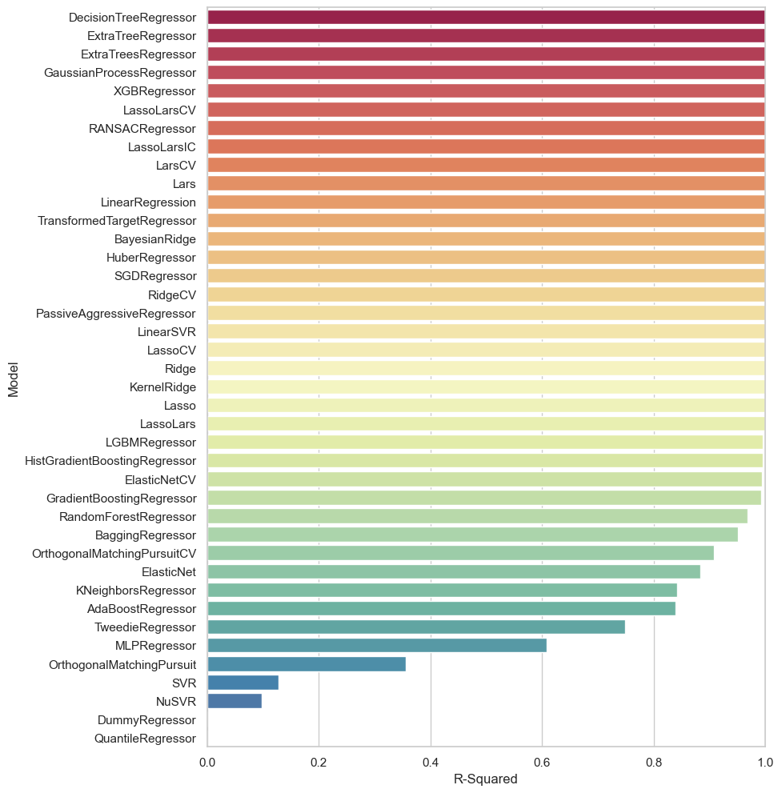

```python
# Set figure size
plt.figure(figsize=(9, 12))
# Set Seaborn theme
sns.set_theme(style="whitegrid")
# Use a gradient color palette (like "viridis", "coolwarm", or "Spectral")
ax = sns.barplot(
 y=predictions_train.index,
 x="R-Squared",
 data=predictions_train,
 palette=sns.color_palette("Spectral", len(predictions_train))
)
# Set X-axis limits
ax.set(xlim=(0, 1))
# Show plot
plt.show()
```

Bar plot of RMSE values

```
[(0.0, 10.0)]
```

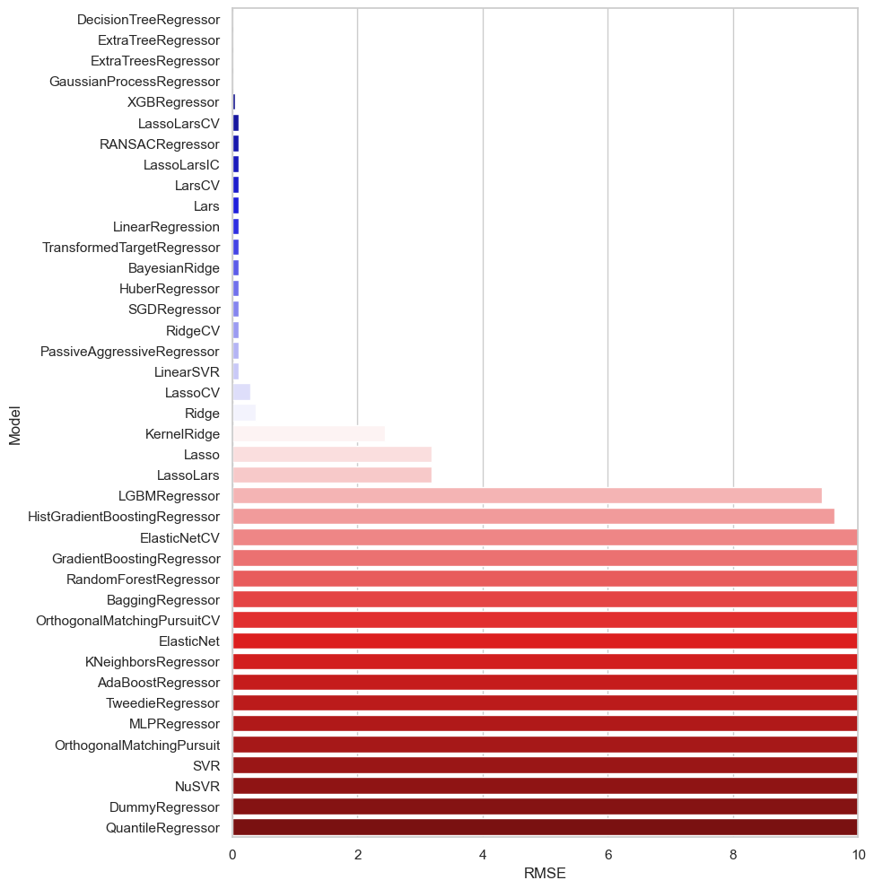

```python
plt.figure(figsize=(9, 12))
sns.set_theme(style="whitegrid")
ax = sns.barplot(y=predictions_train.index, x="RMSE", data=predictions_train,palette=sns.color_palette("seismic", len(predictions_train)))
ax.set(xlim=(0, 10))
```

## Bar plot of calculation time

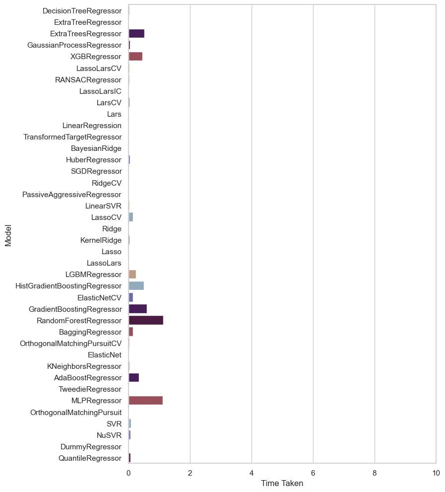

```python
plt.figure(figsize=(8, 12))
sns.set_theme(style="whitegrid")

ax = sns.barplot(y=predictions_train.index, x="Time Taken", data=predictions_train,
                 palette=sns.color_palette("twilight"))

ax.set(xlim=(0, 10))
plt.show()
```